# emm_pa_sil

Minghui Wang

2025-03-27

# 2008–2018 for HRS (waves 9–14),

## Data Import

PS: Data from 2019 onward include the COVID-19 period, which represents a major confounding factor in our study.

This population-based, cross-national cohort study used longitudinal data from three cohorts of adults aged 60 years and older: HRS, ELSA, and MHAS. These cohorts included data on participants’ physical activities, social activities, loneliness, and depressive symptoms. To ensure comparability across surveys, we analyzed data from similar time periods: 2008–2018 for HRS (waves 9–14), 2010–2018 for ELSA (waves 5–9), and 2012–2018 for MHAS (waves 3–5).

```r
HRS_raw = read_sav("./data/HRS/randhrs1992_2020v2.sav")
```

### Load wave 9 data

```r
library(SAScii)

# 设置文件路径（请替换为您的实际路径）
fn = "./data/HRS/h08core/h08da/H08LB_R.da"
sas.input <- "./data/HRS/h08core/h08sas/H08LB_R.sas"
x <- read.SAScii( fn , sas.input )
```

[output not shown]

```r
social_isolation_df <- x |>
  mutate(
    # 1. 未婚/独居
    unmarried_alone = case_when(
      LLB004 == 5 ~ 1,
      !is.na(LLB004) ~ 0,
      TRUE ~ NA_real_
    ),

    # 2. 与子女联系少于每月一次
    less_child_contact = case_when(
      # 任何一个变量>=4或全部缺失
      (LLB009A >= 4 | is.na(LLB009A)) &
      (LLB009B >= 4 | is.na(LLB009B)) &
      (LLB009C >= 4 | is.na(LLB009C)) &
      !(is.na(LLB009A) & is.na(LLB009B) & is.na(LLB009C)) ~ 1,
      # 至少有一个变量<4
      LLB009A < 4 | LLB009B < 4 | LLB009C < 4 ~ 0,
      TRUE ~ NA_real_
    ),

    # 3. 与其他家庭成员联系少于每月一次
    less_family_contact = case_when(
      (LLB013A >= 4 | is.na(LLB013A)) &
      (LLB013B >= 4 | is.na(LLB013B)) &
      (LLB013C >= 4 | is.na(LLB013C)) &
      !(is.na(LLB013A) & is.na(LLB013B) & is.na(LLB013C)) ~ 1,
      LLB013A < 4 | LLB013B < 4 | LLB013C < 4 ~ 0,
      TRUE ~ NA_real_
    ),

    # 4. 与朋友联系少于每月一次
    less_friends_contact = case_when(
      (LLB017A >= 4 | is.na(LLB017A)) &
      (LLB017B >= 4 | is.na(LLB017B)) &
      (LLB017C >= 4 | is.na(LLB017C)) &
      !(is.na(LLB017A) & is.na(LLB017B) & is.na(LLB017C)) ~ 1,
      LLB017A < 4 | LLB017B < 4 | LLB017C < 4 ~ 0,
      TRUE ~ NA_real_
    ),

    # 5. 不参加每月的社交组织活动
    no_social_participation = case_when(
      # 如果有任何一个变量是1或2，说明参与了社交活动
      (LLB001B %in% c(1, 2) & !is.na(LLB001B)) |
      (LLB001C %in% c(1, 2) & !is.na(LLB001C)) |
      (LLB001E %in% c(1, 2) & !is.na(LLB001E)) |
      (LLB001F %in% c(1, 2) & !is.na(LLB001F)) |
      (LLB001J %in% c(1, 2) & !is.na(LLB001J)) ~ 0,
      # 如果所有非NA变量都不是1或2，且至少有一个非NA变量
      !all(is.na(c(LLB001B, LLB001C, LLB001E, LLB001F, LLB001J))) ~ 1,
      TRUE ~ NA_real_
    )
  ) |>
  # 计算非NA组件的总和
  rowwise() |>
  mutate(
    # 计算有多少个非NA的社交隔离指标
    valid_components = sum(!is.na(c(unmarried_alone, less_child_contact,
                                    less_family_contact, less_friends_contact,
                                    no_social_participation))),

    # 计算可用的社交隔离分数
    sum_valid = sum(c(unmarried_alone, less_child_contact,
                      less_family_contact, less_friends_contact,
                      no_social_participation), na.rm = TRUE),

    # 如果至少有3个有效指标，则计算社交隔离指数
    social_isolation_index = case_when(
      valid_components >= 3 ~ sum_valid,
      TRUE ~ NA_real_
    ),

    # 分类变量：2分及以上为社交隔离
    social_isolation = ifelse(social_isolation_index >= 2, 1, 0)
  ) |>
  ungroup() |>
  # 选择需要的列
  select(HHID, social_isolation_index, social_isolation) |>
  # 移除仍然有NA的行
  filter(!is.na(social_isolation))
```

Criterion Description Variable to Use (1) were unmarried/living alone: LLB004 (2) had less than monthly contact with children (all contacts, including face-to-face meet up, speak on the phone, write, or email): LB009A ,LLB009B,LLB009C (3) had less than monthly contact with other family members:LLB013A, LLB013B, LLB013C (4) had less than monthly contact with friends: LLB017A, LLB017B,LLB017C (5) did not participate monthly in any groups, clubs, or other social organizations: LLB001B ,LLB001C, LLB001E, LLB001F, LLB001J

## Data Cleaning

```r
# Select columns starting with R9, R10, R11, R12, R13, and R4, plus HHIDPN
all_cols <- names(HRS_raw)
r_cols <- all_cols[grepl("^R(9|10|11|12|13|14)", all_cols)]

# 选择 S9 wave 的关键 demographic 变量
s_baseline_cols <- c(
  "RAGENDER", "RAEDUC", "RAHISPAN", "RARACEM",  # 性别、教育、种族
  "RABMONTH", "RABYEAR", "RAEDYRS", "RAEDEGRM" # 出生月年、教育年数、学位
)

selected_cols <- c("HHIDPN", s_baseline_cols, r_cols)

# Create the new dataframe with selected columns
HRS_9_14 <- HRS_raw[, selected_cols] |>
  filter(R9IWSTAT == 1 | R10IWSTAT == 1 | R11IWSTAT == 1 |
         R12IWSTAT == 1 | R13IWSTAT == 1 | R14IWSTAT == 1)
```

28575 unique individuals in HRA from 2008 to 2018 (waves 9–14)

```r
HRS_9_14_inclusion = HRS_9_14 |>
  #Age < 55
    mutate(
    estimated_age_at_R9 = case_when(
      !is.na(R9AGEY_E) ~ R9AGEY_E,
      !is.na(R10AGEY_E) ~ R10AGEY_E - 2,
      !is.na(R11AGEY_E) ~ R11AGEY_E - 4,
      !is.na(R12AGEY_E) ~ R12AGEY_E - 6,
      !is.na(R13AGEY_E) ~ R13AGEY_E - 8,
      !is.na(R14AGEY_E) ~ R14AGEY_E - 10,
      TRUE ~ NA_real_
    )
  )|>
  filter( estimated_age_at_R9 >= 55)|>
# information of depression: NA or Yes
  filter(!is.na(R9CESD))|>
  filter(R9CESD < 2)|>
# Any missing data in baseline characteristics

  filter(
     #!is.na(R9SOCGRP),  Social activities
    !is.na(R9FLONE), #  felt loneliness
    !is.na(RAGENDER),# sex
    !is.na(R9MSTAT),# marital status
    !is.na(RAEDUC),# Education
    !is.na(R9FINR), # Family income
    !is.na(R9LBRF), # Employment status
    !is.na(R9BMI),#BMI

    !is.na(R9DRINK))|># Alcohol consumption
    #PA
  mutate(across(
    .cols = c(R9VGACTX, R9MDACTX),
    .fns = ~ if_else(. %in% c('.D', '.J', '.M', '.R'), NA_real_, as.numeric(.))
  )) %>%
  # 2. 分别将“1,2,3=活跃(0)；4,5=不活跃(1)”进行二值转换
  mutate(
    vigorous_inactive = case_when(
      R9VGACTX %in% c(4, 5) ~ 1,   # 1-3次/月 或 几乎没有
      R9VGACTX %in% c(1, 2, 3) ~ 0, # 至少每周1次
      TRUE ~ NA_real_
    ),
    moderate_inactive = case_when(
      R9MDACTX %in% c(4, 5) ~ 1,   # 1-3次/月 或 几乎没有
      R9MDACTX %in% c(1, 2, 3) ~ 0, # 至少每周1次
      TRUE ~ NA_real_
    )
  ) %>%
  # 3. 综合：如果你想“只要有任一题目足够活跃 => 整体 = 0；只有当两题都不活跃 => 整体 = 1”
  #   那么 physical_inactivity_binary = 1 当 vigorous_inactive=1 且 moderate_inactive=1
  #   否则 physical_inactivity_binary=0
  mutate(
    physical_inactivity_binary = case_when(
      vigorous_inactive == 1 & moderate_inactive == 1 ~ 1,  # 两个都不活跃 => 不活跃
      (!is.na(vigorous_inactive) & vigorous_inactive == 0) |
      (!is.na(moderate_inactive) & moderate_inactive == 0) ~ 0, # 任一活跃 => 整体活跃
      TRUE ~ NA_real_
    ),
    # 如需转成因子
    physical_inactivity = factor(
      physical_inactivity_binary,
      levels = c(0, 1),
      labels = c("No", "Yes")
    )
  )|>
  # smoking
    mutate(
    Smoking = case_when(
      # 当前吸烟者(Current smoker)
      R9SMOKEN == 1 ~ "Current smoker",

      # 曾经吸烟但现在不吸烟者(Former smoker)
      R9SMOKEN == 0 & R9SMOKEV == 1 ~ "Former smoker",

      # 从不吸烟者(Non-smoker)
      R9SMOKEN == 0 & R9SMOKEV == 0 ~ "Non-smoker",

      # 处理缺失值
      TRUE ~ NA_character_
    )
  )|>
    # NCDs
     mutate(
    ncd_count = rowSums(
      cbind(
        R9HIBP,    # Hypertension
        R9HEART,   # Heart disease
        R9STROKE,  # Stroke
        R9DIAB,    # Diabetes
        R9LUNG,    # Lung disease (e.g., COPD)
        R9CANCR,   # Cancer
        R9ARTHR    # Arthritis
      ) == 1,      # Count only positive responses
      na.rm = TRUE
    )
  ) |>
   filter(!is.na(ncd_count),!is.na(Smoking), !is.na(physical_inactivity))
```

```r
# 第1步：从HHIDPN中提取HHID和PN
hhid_pn_mapping <- HRS_9_14_inclusion |>
  mutate(
    HHID = floor(HHIDPN / 1000),
    PN = HHIDPN %% 1000
  ) |>
  select(HHIDPN, HHID, PN) |>
  distinct()

# 第2步：将social_isolation_df中的HHID扩展为HHIDPN
social_isolation_with_pn <- social_isolation_df |>
  # 确保HHID是字符型（如果需要）
  mutate(HHID = as.numeric(HHID)) |>
  # 与HHID-PN映射表合并
  inner_join(hhid_pn_mapping, by = "HHID") |>
  # 选择需要的列
  select(HHIDPN, social_isolation_index, social_isolation)
# 第3步：将扩展后的社交隔离数据与原始数据集合并
HRS_9_14_inclusion_sii <- HRS_9_14_inclusion |>
  left_join(social_isolation_with_pn, by = "HHIDPN")|>
  filter(
    !is.na(social_isolation)
  )

# 检查合并结果
dim(HRS_9_14_inclusion_sii)
```

```
## [1] 7428 3531
```

```r
HRS_9_14_inclusion_final <- HRS_9_14_inclusion_sii %>%
  rowwise() %>%
  mutate(num_cesd_waves = sum(!is.na(c_across(starts_with("R") & ends_with("CESD"))))) %>%
  ungroup() %>%
  filter(num_cesd_waves >= 2)  # 至少2次CES-D测量

dim(HRS_9_14_inclusion_final)
```

```
## [1] 6831 3532
```

## Select desired Variables

```r
HRS_9_14_inclusion_final_df = HRS_9_14_inclusion_final|>
  select(
      HHIDPN,
      #Exposure
      social_isolation, # social isolation
      #lonely
      R9FLONE,R9LBLONELY3,
      # Outcomes:
      R9CESD,R10CESD,R11CESD,R12CESD,R13CESD,R14CESD, #depression
      #EMM:
      physical_inactivity,
      # Baseline characteristics
      estimated_age_at_R9, # Median age (IQR), years
      RAGENDER,# Sex
      R9MSTAT,# Marital status
      RAEDUC,# Education
      RARACEM,RAHISPAN, #Race
      R9FINR, # Family income
      R9LBRF, # Employment status
      R9BMI,#BMI
      Smoking,# Smoking
      R9DRINK,# Alcohol consumption
      ncd_count) |># NCDs
    rename(
        # Baseline characteristics
        "Age" = estimated_age_at_R9,
        "Sex" = RAGENDER,
        "Marital_status" = R9MSTAT,
        "Education" = RAEDUC,
        "Family_income" = R9FINR,
        "Employment_status" = R9LBRF,
        "BMI" = R9BMI,
        "Alcohol_consumption" = R9DRINK,
        "Non_communicable_diseases" = ncd_count
      )|>
  #lonely
   mutate(
    # 处理三项 R-UCLA 平均分：
    # 先将平均分乘以 3，得到各题得分之和（范围 3～9），
    # 如果乘3后的值 ≥ 4 则认定为孤独（1），否则为不孤独（0）。
    lonely_three = case_when(
      !is.na(R9LBLONELY3) ~ if_else(R9LBLONELY3 * 3 >= 4, 1, 0),
      TRUE ~ NA_real_
    ),
    # 处理单项测量变量 R9FLONE：
    # 若 R9FLONE ≥ 1 则认定为孤独（1），否则为不孤独（0）
    lonely_single = case_when(
      !is.na(R9FLONE) ~ if_else(R9FLONE >= 1, 1, 0),
      TRUE ~ NA_real_
    ),
    # 综合两种测量：
    # 若任一指标有效且为 1，则最终判定为孤独；
    # 若两项均有效且均为 0，则判定为不孤独；
    # 若其中一项缺失，则采用有效项的结果；若两项均缺失则为 NA。
    Loneliness = case_when(
      (!is.na(lonely_three) & lonely_three == 1) | (!is.na(lonely_single) & lonely_single == 1) ~ 1,
      !is.na(lonely_three) & !is.na(lonely_single) & lonely_three == 0 & lonely_single == 0 ~ 0,
      !is.na(lonely_three) & is.na(lonely_single) ~ lonely_three,
      is.na(lonely_three) & !is.na(lonely_single) ~ lonely_single,
      TRUE ~ NA_real_
    )
  )|>
    # RACE
     mutate(
        race = case_when(
          # Missing if either variable is missing
          is.na(RARACEM) | is.na(RAHISPAN) ~ "Missing",

          # Hispanic (any race)
          RAHISPAN == 1 ~ "Hispanic",

          # Non-Hispanic by race
          RAHISPAN == 0 & RARACEM == 1 ~ "White/Caucasian",
          RAHISPAN == 0 & RARACEM == 2 ~ "Black/African American",
          RAHISPAN == 0 & RARACEM %in% c(3, 4, 5, 6, 7) ~ "Other", # Assuming other race codes

          # Default case
          TRUE ~ "Other"
        )
      ) |>
      # Convert to factor with specified levels
      mutate(
        race = factor(race,
                      levels = c("White/Caucasian", "Black/African American", "Hispanic", "Other", "Missing"))
      )
```

Create df for cox analysis

```r
# Create variables for Cox regression analysis
HRS_9_14_inclusion_cox_df = HRS_9_14_inclusion_final_df |>
  mutate(
    depression_event = case_when(
      # Check for depression in any follow-up wave
      ((!is.na(R10CESD) & R10CESD >= 2) |
       (!is.na(R11CESD) & R11CESD >= 2) |
       (!is.na(R12CESD) & R12CESD >= 2) |
       (!is.na(R13CESD) & R13CESD >= 2) |
       (!is.na(R14CESD) & R14CESD >= 2)) ~ 1,
      # Otherwise censored
      TRUE ~ 0
    ),
    follow_up_time = case_when(
      depression_event == 1 & R10CESD >= 2 ~ 2,
      depression_event == 1 & R11CESD >= 2 & (is.na(R10CESD) | R10CESD < 2) ~ 4,
      depression_event == 1 & R12CESD >= 2 & (is.na(R11CESD) | R11CESD < 2) ~ 6,
      depression_event == 1 & R13CESD >= 2 & (is.na(R12CESD) | R12CESD < 2) ~ 8,
      depression_event == 1 & R14CESD >= 2 & (is.na(R13CESD) | R13CESD < 2) ~ 10,
      depression_event == 0 & !is.na(R14CESD) ~ 10,
      depression_event == 0 & !is.na(R13CESD) & is.na(R14CESD) ~ 8,
      depression_event == 0 & !is.na(R12CESD) & is.na(R13CESD) ~ 6,
      depression_event == 0 & !is.na(R11CESD) & is.na(R12CESD) ~ 4,
      depression_event == 0 & !is.na(R10CESD) & is.na(R11CESD) ~ 2,
      TRUE ~ NA_real_
    )
  ) |>
  select(-RAHISPAN, -RARACEM, -ends_with("CESD"), -ends_with("ACTX"),  -Family_income) |>
  mutate(
    social_isolation = factor(social_isolation, levels = c(1, 0), labels = c("isolated", "integrated")),
    Loneliness = factor(Loneliness, levels = c(0, 1), labels = c("Not lonely", "Lonely")),
    Sex = factor(Sex, levels = c(1, 2), labels = c("Male", "Female")),
    Marital_status = factor(Marital_status, levels = c(1,2,3,4,5,6,7,8),
                            labels = c("Married or partnered", "Married or partnered", "Married or partnered",
                                       "Single", "Single", "Single", "Single", "Single")),
    Education = factor(Education, levels = c(1,2,3,4,5),
                       labels = c("Less than upper secondary", "Upper secondary", "Upper secondary", "Tertiary", "Tertiary")),
    Employment_status = case_when(
      as.character(Employment_status) %in% c("1", "2", "4") ~ "Working",
      as.character(Employment_status) %in% c("5", ".A") ~ "Retired",
      as.character(Employment_status) %in% c("3", "6", "7", ".T", ".Q") ~ "Not working",
      TRUE ~ NA_character_
    ),
    Employment_status = factor(Employment_status, levels = c("Working", "Retired", "Not working")),
    BMI = case_when(
      BMI < 25 ~ "Underweight or healthy weight",
      BMI >= 25 & BMI < 30 ~ "Overweight",
      BMI >= 30 ~ "Obesity"
    ),
    BMI = factor(BMI, levels = c("Underweight or healthy weight", "Overweight", "Obesity")),

    Smoking = factor(Smoking),

    Alcohol_consumption = factor(Alcohol_consumption, levels = c(0,1), labels = c("No", "Yes")),

    Non_communicable_diseases = factor(ifelse(Non_communicable_diseases == 0, "None", "One or more"))
  )


#write.csv(HRS_9_14_inclusion_cox_df, "./data/cleaned/HRS_9_14_cox.csv", row.names = FALSE)
```

## EDA

```r
# 安装和加载tableone包
if(!require(tableone)) install.packages("tableone")
library(tableone)

# 定义要包含在表中的变量
vars <- c("Age", "Sex", "race", "Marital_status", "Education", "Employment_status",
          "BMI", "Smoking", "Alcohol_consumption", "Non_communicable_diseases",
          "social_isolation", "Loneliness")

# 定义哪些变量是分类变量
categorical_vars <- c("social_isolation","Loneliness", "Sex", "race", "Marital_status", "Education", "Employment_status",
                     "Smoking", "Alcohol_consumption", "Non_communicable_diseases")

# 创建Table 1
table1_HRS <- CreateTableOne(
  vars = vars,
  strata = "physical_inactivity",
  data = HRS_9_14_inclusion_cox_df,
  factorVars = categorical_vars
)
table1_HRS
```

```
##                                              Stratified by physical_inactivity
##                                               No            Yes
##   n                                            5421          1410
##   Age (mean (SD))                             68.70 (8.14)  70.04 (9.01)
##   Sex = Female (%)                             2746 (50.7)    828 (58.7)
##   race (%)
##      White/Caucasian                           4448 (82.1)   1059 (75.1)
##      Black/African American                     510 ( 9.4)    205 (14.5)
##      Hispanic                                   360 ( 6.6)    107 ( 7.6)
##      Other                                      101 ( 1.9)     39 ( 2.8)
##      Missing                                      2 ( 0.0)      0 ( 0.0)
##   Marital_status = Single (%)                   970 (17.9)    315 (22.3)
##   Education (%)
##      Less than upper secondary                  672 (12.4)    296 (21.0)
##      Upper secondary                           1895 (35.0)    570 (40.4)
##      Tertiary                                  2854 (52.6)    544 (38.6)
##   Employment_status (%)
##      Working                                   2116 (39.0)    495 (35.1)
##      Retired                                   2895 (53.4)    777 (55.1)
##      Not working                                410 ( 7.6)    138 ( 9.8)
##   BMI (%)
##      Underweight or healthy weight             1678 (31.0)    314 (22.3)
##      Overweight                                2266 (41.8)    488 (34.6)
##      Obesity                                   1477 (27.2)    608 (43.1)
##   Smoking (%)
##      Current smoker                             477 ( 8.8)    193 (13.7)
##      Former smoker                             2551 (47.1)    633 (44.9)
##      Non-smoker                                2393 (44.1)    584 (41.4)
##   Alcohol_consumption = Yes (%)                3229 (59.6)    682 (48.4)
##   Non_communicable_diseases = One or more (%)  4618 (85.2)   1288 (91.3)
##   social_isolation = integrated (%)            3726 (68.7)    897 (63.6)
##   Loneliness = Lonely (%)                      2320 (42.8)    674 (47.8)
##                                              Stratified by physical_inactivity
##                                               p      test
##   n
##   Age (mean (SD))                             <0.001
##   Sex = Female (%)                            <0.001
##   race (%)                                    <0.001
##      White/Caucasian
##      Black/African American
```

[output cut: 9 more lines]

```
##      Working
##      Retired
##      Not working
##   BMI (%)                                     <0.001
##      Underweight or healthy weight
##      Overweight
##      Obesity
##   Smoking (%)                                 <0.001
##      Current smoker
##      Former smoker
##      Non-smoker
##   Alcohol_consumption = Yes (%)               <0.001
##   Non_communicable_diseases = One or more (%) <0.001
##   social_isolation = integrated (%)           <0.001
##   Loneliness = Lonely (%)                      0.001
```

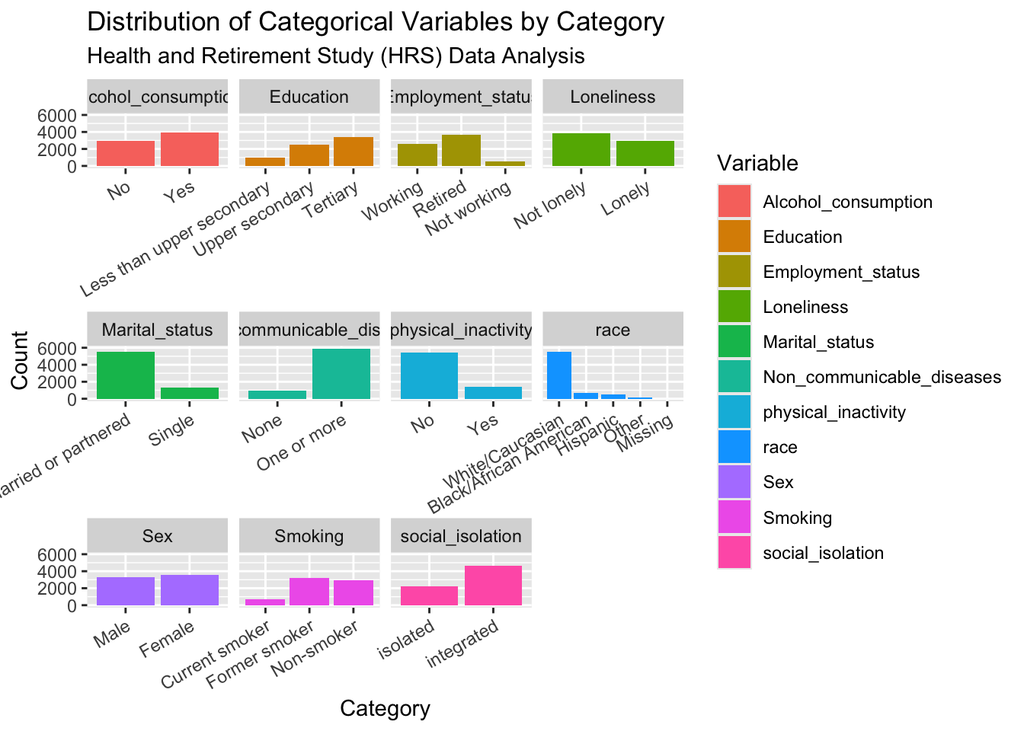

```r
HRS_9_14_inclusion_cox_df　|>
  select(categorical_vars, physical_inactivity)|>
  pivot_longer(cols = everything(), names_to = "Variable", values_to = "Value")|>
  ggplot(aes(x = factor(Value), fill = Variable)) +
  geom_bar() +
  facet_wrap(~ Variable, scales = "free_x") +
  labs(
    title = "Distribution of Categorical Variables by Category",
    subtitle = "Health and Retirement Study (HRS) Data Analysis",
    x = "Category",
    y = "Count"
  ) +
  theme(axis.text.x = element_text(angle = 30, hjust = 1))
```

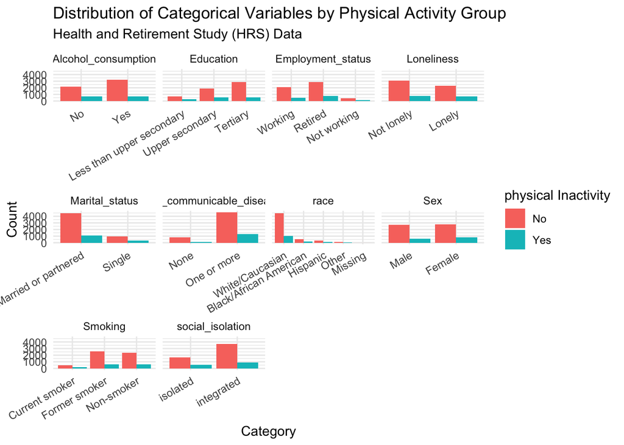

```r
HRS_9_14_inclusion_cox_df |>
  select(physical_inactivity, categorical_vars) |>
  pivot_longer(cols = -physical_inactivity, names_to = "Variable", values_to = "Value") |>
  ggplot(aes(x = factor(Value), fill = factor(physical_inactivity))) +
  geom_bar(position = "dodge") +   # 改为 "fill" 可以显示比例
  facet_wrap(~ Variable, scales = "free_x") +
  labs(
    title = "Distribution of Categorical Variables by Physical Activity Group",
    subtitle = "Health and Retirement Study (HRS) Data",
    x = "Category",
    y = "Count",
    fill = "physical Inactivity"
  ) +
  theme_minimal() +
  theme(axis.text.x = element_text(angle = 30, hjust = 1))
```

## Cox model

```r
hrs_data_std <- HRS_9_14_inclusion_cox_df %>%
  rename(
    id = HHIDPN,
    isolation = social_isolation,
    loneliness = Loneliness,
    age = Age,
    sex = Sex,
    mar_status = Marital_status,
    education = Education,
    employment = Employment_status,
    bmi = BMI,
    smoking = Smoking,
    alcohol = Alcohol_consumption,
    ncd = Non_communicable_diseases,
    event = depression_event,
    time = follow_up_time
  ) %>%
  mutate(data_source = "HRS")
```

### Loneliness

```r
# 模型1：仅包含 loneliness 的单变量模型
cox_model_lonely_raw <- coxph(Surv(time, event) ~ loneliness, data = hrs_data_std)

# 模型2：调整协变量模型（不含身体活动）
cox_model_lonely_adj <- coxph(Surv(time, event) ~ loneliness + age + sex + race + mar_status + education + employment +
                              bmi + smoking + alcohol + ncd,
                              data = hrs_data_std)

# 模型3：调整协变量模型，额外加入 physical_inactivity 作为共变量
cox_model_lonely_pi <- coxph(Surv(time, event) ~ loneliness + physical_inactivity + age + sex + race + mar_status + education + employment +
                             bmi + smoking + alcohol + ncd,
                             data = hrs_data_std)

# 模型4：包含 loneliness 与 physical_inactivity 交互项的模型
cox_model_lonely_emm <- coxph(Surv(time, event) ~ loneliness * physical_inactivity + age + sex + race + mar_status + education + employment +
                              bmi + smoking + alcohol + ncd,
                              data = hrs_data_std)
```

```r
#提取结果

## 模型1结果
summary_lonely_raw <- summary(cox_model_lonely_raw)
hr1      <- summary_lonely_raw$conf.int["lonelinessLonely", "exp(coef)"]
lower1   <- summary_lonely_raw$conf.int["lonelinessLonely", "lower .95"]
upper1   <- summary_lonely_raw$conf.int["lonelinessLonely", "upper .95"]
p1       <- summary_lonely_raw$coefficients["lonelinessLonely", "Pr(>|z|)"]

## 模型2结果
summary_lonely_adj <- summary(cox_model_lonely_adj)
hr2      <- summary_lonely_adj$conf.int["lonelinessLonely", "exp(coef)"]
lower2   <- summary_lonely_adj$conf.int["lonelinessLonely", "lower .95"]
upper2   <- summary_lonely_adj$conf.int["lonelinessLonely", "upper .95"]
p2       <- summary_lonely_adj$coefficients["lonelinessLonely", "Pr(>|z|)"]

## 模型3结果
summary_lonely_pi <- summary(cox_model_lonely_pi)
hr3      <- summary_lonely_pi$conf.int["lonelinessLonely", "exp(coef)"]
lower3   <- summary_lonely_pi$conf.int["lonelinessLonely", "lower .95"]
upper3   <- summary_lonely_pi$conf.int["lonelinessLonely", "upper .95"]
p3       <- summary_lonely_pi$coefficients["lonelinessLonely", "Pr(>|z|)"]

## 模型4结果 - loneliness 主效应
summary_lonely_emm <- summary(cox_model_lonely_emm)
hr4      <- summary_lonely_emm$conf.int["lonelinessLonely", "exp(coef)"]
lower4   <- summary_lonely_emm$conf.int["lonelinessLonely", "lower .95"]
upper4   <- summary_lonely_emm$conf.int["lonelinessLonely", "upper .95"]
p4       <- summary_lonely_emm$coefficients["lonelinessLonely", "Pr(>|z|)"]

## 交互项效果（乘法交互）提取
# 假设交互项名称为 "lonelinessLonely:physical_inactivityYes"
interaction_term <- "lonelinessLonely:physical_inactivityYes"
interaction_coef <- summary_lonely_emm$coefficients[interaction_term, "coef"]
interaction_hr   <- summary_lonely_emm$conf.int[interaction_term, "exp(coef)"]
interaction_lower<- summary_lonely_emm$conf.int[interaction_term, "lower .95"]
interaction_upper<- summary_lonely_emm$conf.int[interaction_term, "upper .95"]
interaction_p    <- summary_lonely_emm$coefficients[interaction_term, "Pr(>|z|)"]

cat("【乘法交互】\n")
```

```
## 【乘法交互】
```

```r
cat("交互项系数:", interaction_coef, "\n")
```

```
## 交互项系数: 0.01413899
```

```r
cat("交互项 HR (exp(coef)):", interaction_hr, "\n")
```

```
## 交互项 HR (exp(coef)): 1.014239
```

```r
cat("95% CI:", interaction_lower, "-", interaction_upper, "\n")
```

```
## 95% CI: 0.8511302 - 1.208607
```

```r
cat("p 值:", interaction_p, "\n\n")
```

```
## p 值: 0.8744122
```

```r
########################################
## 3.1 Additive interaction (RERI) 计算
########################################
# 提取各参数系数
beta_lonely <- summary_lonely_emm$coefficients["lonelinessLonely", "coef"]     # loneliness 主效应
beta_pi     <- summary_lonely_emm$coefficients["physical_inactivityYes", "coef"] # physical_inactivity 主效应
beta_int    <- interaction_coef                                               # 交互项

# 计算各暴露组合的 HR
HR10 <- exp(beta_lonely)                      # loneliness alone (physical_inactivity = 0)
HR01 <- exp(beta_pi)                          # physical_inactivity alone (loneliness = 0)
HR11 <- exp(beta_lonely + beta_pi + beta_int)  # both exposures

RERI <- HR11 - HR10 - HR01 + 1

cat("【加性交互 (RERI)】\n")
```

```
## 【加性交互 (RERI)】
```

```r
cat("HR (loneliness alone) =", HR10, "\n")
```

```
## HR (loneliness alone) = 1.768886
```

```r
cat("HR (physical_inactivity alone) =", HR01, "\n")
```

```
## HR (physical_inactivity alone) = 1.202077
```

```r
cat("HR (both exposures) =", HR11, "\n")
```

```
## HR (both exposures) = 2.156615
```

```r
cat("RERI =", RERI, "\n")
```

```
## RERI = 0.1856519
```

```r
##############################################
## 计算 RERI 的标准误、95% CI 和 p 值 (Delta 方法)
##############################################
# 获取交互模型的协方差矩阵，并提取相关参数的子矩阵
V <- vcov(cox_model_lonely_emm)
param_names <- c("lonelinessLonely", "physical_inactivityYes", interaction_term)
V_sub <- V[param_names, param_names]

# 计算 RERI 关于各系数的偏导数
d_beta <- c(
  exp(beta_lonely + beta_pi + beta_int) - exp(beta_lonely), # ∂RERI/∂β_lonely
  exp(beta_lonely + beta_pi + beta_int) - exp(beta_pi),      # ∂RERI/∂β_pi
  exp(beta_lonely + beta_pi + beta_int)                       # ∂RERI/∂β_int
)

Var_RERI <- as.numeric(t(d_beta) %*% V_sub %*% d_beta)
SE_RERI <- sqrt(Var_RERI)

RERI_lower <- RERI - 1.96 * SE_RERI
RERI_upper <- RERI + 1.96 * SE_RERI

z_RERI <- RERI / SE_RERI
p_RERI <- 2 * (1 - pnorm(abs(z_RERI)))

cat("\n【RERI 结果】\n")
```

```
##
## 【RERI 结果】
```

```r
cat("RERI =", RERI, "\n")
```

```
## RERI = 0.1856519
```

```r
cat("95% CI: (", RERI_lower, ",", RERI_upper, ")\n")
```

```
## 95% CI: ( -0.09618261 , 0.4674864 )
```

```r
cat("z =", z_RERI, "\n")
```

```
## z = 1.291104
```

```r
cat("p 值 =", p_RERI, "\n")
```

```
## p 值 = 0.1966675
```

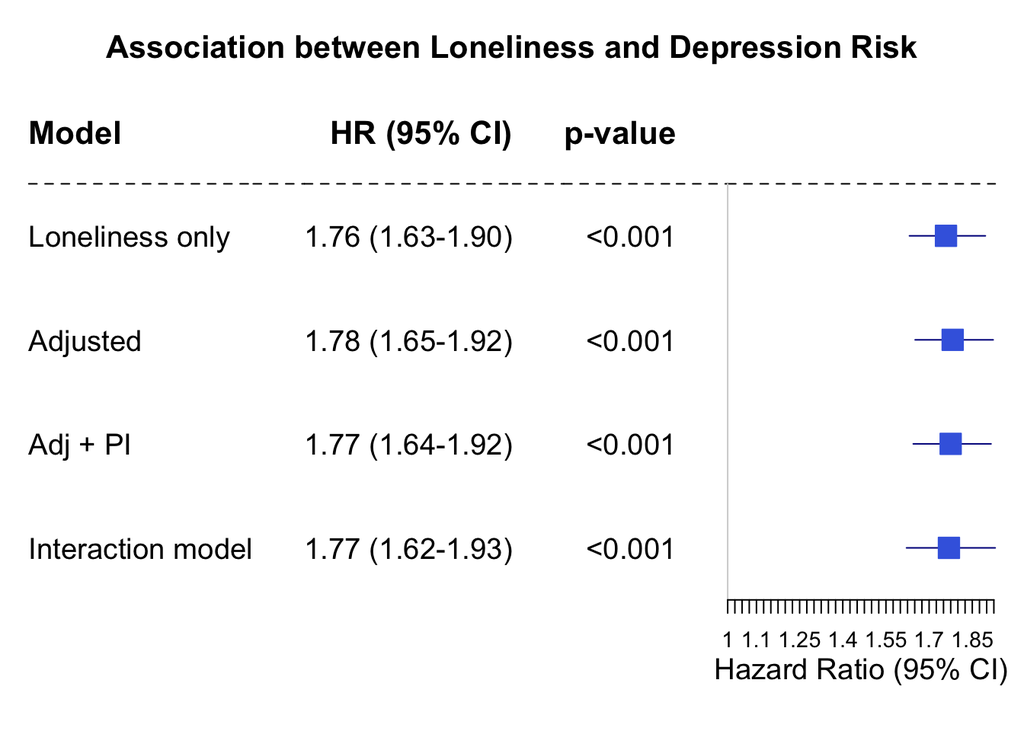

```r
######################################
## 4. 森林图绘制 - Loneliness 系列模型
######################################
tabletext <- cbind(
  c("Model", "Loneliness only", "Adjusted", "Adj + PI", "Interaction model"),
  c("HR (95% CI)",
    paste0(sprintf("%.2f", hr1), " (", sprintf("%.2f", lower1), "-", sprintf("%.2f", upper1), ")"),
    paste0(sprintf("%.2f", hr2), " (", sprintf("%.2f", lower2), "-", sprintf("%.2f", upper2), ")"),
    paste0(sprintf("%.2f", hr3), " (", sprintf("%.2f", lower3), "-", sprintf("%.2f", upper3), ")"),
    paste0(sprintf("%.2f", hr4), " (", sprintf("%.2f", lower4), "-", sprintf("%.2f", upper4), ")")
  ),
  c("p-value",
    ifelse(p1 < 0.001, "<0.001", sprintf("%.3f", p1)),
    ifelse(p2 < 0.001, "<0.001", sprintf("%.3f", p2)),
    ifelse(p3 < 0.001, "<0.001", sprintf("%.3f", p3)),
    ifelse(p4 < 0.001, "<0.001", sprintf("%.3f", p4)))
)

forest_data <- data.frame(
  mean = c(NA, hr1, hr2, hr3, hr4),
  lower = c(NA, lower1, lower2, lower3, lower4),
  upper = c(NA, upper1, upper2, upper3, upper4)
)

forestplot(
  labeltext = tabletext,
  mean = forest_data$mean,
  lower = forest_data$lower,
  upper = forest_data$upper,
  is.summary = c(TRUE, FALSE, FALSE, FALSE, FALSE),
  zero = 1,
  boxsize = 0.2,
  lineheight = "auto",
  col = fpColors(box = "royalblue", line = "darkblue", summary = "royalblue"),
  xlab = "Hazard Ratio (95% CI)",
  hrzl_lines = list("2" = gpar(lty = 2)),
  txt_gp = fpTxtGp(label = gpar(cex = 1.2),
                   ticks = gpar(cex = 0.9),
                   xlab = gpar(cex = 1.2),
                   title = gpar(cex = 1.3)),
  title = "Association between Loneliness and Depression Risk"
)
```

### social isolation

```r
###############################
## Social isolation 模型分析 ##
###############################
hrs_data_std$isolation <- relevel(hrs_data_std$isolation, ref = "integrated")
# 模型1：仅包含 isolation 单变量 Cox 模型
cox_model_iso_raw <- coxph(Surv(time, event) ~ isolation, data = hrs_data_std)

# 模型2：调整协变量的 Cox 模型（不含身体活动）
cox_model_iso_adj <- coxph(Surv(time, event) ~ isolation + age + sex + race + mar_status + education + employment +
                             bmi + smoking + alcohol + ncd,
                           data = hrs_data_std)

# 模型3：调整协变量模型，额外控制 physical_inactivity 作为共变量
cox_model_iso_pi <- coxph(Surv(time, event) ~ isolation + physical_inactivity + age + sex + race + mar_status + education + employment +
                            bmi + smoking + alcohol + ncd,
                          data = hrs_data_std)

# 模型4：包含 isolation 与 physical_inactivity 交互项的 Cox 模型
cox_model_iso_emm <- coxph(Surv(time, event) ~ isolation * physical_inactivity + age + sex + race + mar_status + education + employment +
                             bmi + smoking + alcohol + ncd,
                           data = hrs_data_std)
```

```r
###################################
## 结果提取及打印
###################################

# 提取模型1结果（假定 isolation 的待检验水平为 "Socially isolated"）
summary_iso_raw <- summary(cox_model_iso_raw)
hr_iso1       <- summary_iso_raw$conf.int["isolationisolated", "exp(coef)"]
lower_ci_iso1 <- summary_iso_raw$conf.int["isolationisolated", "lower .95"]
upper_ci_iso1 <- summary_iso_raw$conf.int["isolationisolated", "upper .95"]
p_val_iso1    <- summary_iso_raw$coefficients["isolationisolated", "Pr(>|z|)"]

# 提取模型2结果
summary_iso_adj <- summary(cox_model_iso_adj)
hr_iso2       <- summary_iso_adj$conf.int["isolationisolated", "exp(coef)"]
lower_ci_iso2 <- summary_iso_adj$conf.int["isolationisolated", "lower .95"]
upper_ci_iso2 <- summary_iso_adj$conf.int["isolationisolated", "upper .95"]
p_val_iso2    <- summary_iso_adj$coefficients["isolationisolated", "Pr(>|z|)"]

# 提取模型3结果
summary_iso_pi <- summary(cox_model_iso_pi)
hr_iso3       <- summary_iso_pi$conf.int["isolationisolated", "exp(coef)"]
lower_ci_iso3 <- summary_iso_pi$conf.int["isolationisolated", "lower .95"]
upper_ci_iso3 <- summary_iso_pi$conf.int["isolationisolated", "upper .95"]
p_val_iso3    <- summary_iso_pi$coefficients["isolationisolated", "Pr(>|z|)"]

# 提取模型4结果 - isolation 主效应
summary_iso_emm <- summary(cox_model_iso_emm)
hr_iso4       <- summary_iso_emm$conf.int["isolationisolated", "exp(coef)"]
lower_ci_iso4 <- summary_iso_emm$conf.int["isolationisolated", "lower .95"]
upper_ci_iso4 <- summary_iso_emm$conf.int["isolationisolated", "upper .95"]
p_val_iso4    <- summary_iso_emm$coefficients["isolationisolated", "Pr(>|z|)"]

# 交互项效果提取（假设交互项名称为 "isolationisolated:physical_inactivityYes"）
interaction_term_iso <- "isolationisolated:physical_inactivityYes"
interaction_coef_iso <- summary_iso_emm$coefficients[interaction_term_iso, "coef"]
interaction_hr_iso   <- summary_iso_emm$conf.int[interaction_term_iso, "exp(coef)"]
interaction_lower_iso<- summary_iso_emm$conf.int[interaction_term_iso, "lower .95"]
interaction_upper_iso<- summary_iso_emm$conf.int[interaction_term_iso, "upper .95"]
interaction_p_iso    <- summary_iso_emm$coefficients[interaction_term_iso, "Pr(>|z|)"]

cat("【乘法交互】\n")
```

```
## 【乘法交互】
```

```r
cat("交互项系数:", interaction_coef_iso, "\n")
```

```
## 交互项系数: -0.1122299
```

```r
cat("交互项 HR (exp(coef)):", interaction_hr_iso, "\n")
```

```
## 交互项 HR (exp(coef)): 0.8938387
```

```r
cat("95% CI:", interaction_lower_iso, "-", interaction_upper_iso, "\n")
```

```
## 95% CI: 0.7460349 - 1.070925
```

```r
cat("p 值:", interaction_p_iso, "\n\n")
```

```
## p 值: 0.2236246
```

```r
#############################################
## Additive interaction (RERI) 计算
#############################################
# 提取系数：
beta_iso <- summary_iso_emm$coefficients["isolationisolated", "coef"]
beta_pi  <- summary_iso_emm$coefficients["physical_inactivityYes", "coef"]
beta_int <- interaction_coef_iso

# 计算各暴露组合的风险比
HR10 <- exp(beta_iso)                      # isolation alone (physical_inactivity = 0)
HR01 <- exp(beta_pi)                       # physical_inactivity alone (isolation = 0)
HR11 <- exp(beta_iso + beta_pi + beta_int)   # 同时暴露 (both)

RERI <- HR11 - HR10 - HR01 + 1

cat("【加性交互 (RERI)】\n")
```

```
## 【加性交互 (RERI)】
```

```r
cat("HR (isolation only) =", HR10, "\n")
```

```
## HR (isolation only) = 1.060655
```

```r
cat("HR (physical inactivity only) =", HR01, "\n")
```

```
## HR (physical inactivity only) = 1.285039
```

```r
cat("HR (both exposures) =", HR11, "\n")
```

```
## HR (both exposures) = 1.218288
```

```r
cat("RERI =", RERI, "\n")
```

```
## RERI = -0.127407
```

```r
#############################################
## 计算 RERI 的95% CI及 p 值 (Delta 方法)
#############################################
# 获取交互模型的协方差矩阵
V <- vcov(cox_model_iso_emm)
param_names <- c("isolationisolated", "physical_inactivityYes", "isolationisolated:physical_inactivityYes")
V_sub <- V[param_names, param_names]

# 计算 RERI 关于各系数的偏导数
d_beta <- c(
  exp(beta_iso + beta_pi + beta_int) - exp(beta_iso), # dRERI/d(beta_iso)
  exp(beta_iso + beta_pi + beta_int) - exp(beta_pi),    # dRERI/d(beta_pi)
  exp(beta_iso + beta_pi + beta_int)                    # dRERI/d(beta_int)
)

Var_RERI <- as.numeric(t(d_beta) %*% V_sub %*% d_beta)
SE_RERI <- sqrt(Var_RERI)

RERI_lower <- RERI - 1.96 * SE_RERI
RERI_upper <- RERI + 1.96 * SE_RERI

z_RERI <- RERI / SE_RERI
p_RERI <- 2 * (1 - pnorm(abs(z_RERI)))

cat("\n【RERI 的结果】\n")
```

```
##
## 【RERI 的结果】
```

```r
cat("RERI =", RERI, "\n")
```

```
## RERI = -0.127407
```

```r
cat("95% CI: (", RERI_lower, ",", RERI_upper, ")\n")
```

```
## 95% CI: ( -0.3454645 , 0.09065057 )
```

```r
cat("z =", z_RERI, "\n")
```

```
## z = -1.145192
```

```r
cat("p 值 =", p_RERI, "\n")
```

```
## p 值 = 0.2521298
```

# 2010–2018 for ELSA (waves 5–9)

## Baseline

### Data Import

```r
# 读取 wave 4 核心访谈数据baseline

elsa_wave4_core <- read_dta("./data/UKDA-5050-stata/stata/stata13_se/wave_4_elsa_data_v3.dta")
```

```r
elsa_baseline = elsa_wave4_core|>
  # Step 1: 筛选年龄 >= 55 且有CES-D测量 且 baseline无抑郁
  filter(
    indager >= 55  # 年龄变量，dvage 是官方变量
  )|>
  # Step2 CESD:
  mutate(across(
    .cols = c(psceda, pscedg, pscedh, pscedb, pscedc, pscedd, pscedf),
    .fns = ~ na_if(., -9) |> na_if(-8) |> na_if(-2) |> na_if(-1)
  ))|>
  mutate(
    cesd_score = rowSums(cbind(
      psceda == 1,  # 感到抑郁
      pscedg == 1,  # 感到悲伤
      pscedh == 1,  # 难以开始做事
      pscedb == 1,  # 一切都很努力
      pscedc == 1,  # 睡眠不好
      pscedd == 2,  # 不快乐（反向）
      pscedf == 2   # 没有生活乐趣（反向）
    ), na.rm = FALSE),  # ⚠️ 保留 NA,
    depression_event = ifelse(cesd_score >= 2, 1, 0)) |> # Revised CES-D ≥2 = depression)
  # Step2 CESD:Without information about depression at baseline
  filter(!is.na(cesd_score))　|>
  # Step2 CESD:With depression at baseline
  filter(cesd_score < 2)|>
  # Step3: Build loneliness
    #3.1 Build loneliness
      # 3.11. 计算三项 R-UCLA 总分及二值变量（总分≥4判定为孤独）
      mutate(
        loneliness_three = scfeela + scfeelb + scfeelc,
        lonely_three = if_else(loneliness_three >= 4, 1, 0, missing = NA_real_)
      ) %>%
      # 3.12. 处理单项测量 scfeele
      mutate(
        # 仅当 scfeele 为有效回答（1、2、3）时返回1，否则当为负值时视为缺失
        lonely_single = case_when(
          scfeele %in% c(2, 3) ~ 1,
          scfeele == 1 ~ 0,
          scfeele < 0 ~ NA_real_
        )
      ) %>%
      # 3.13. 综合两种测量结果：只要任一指标为1，则定义为孤独
      mutate(
        loneliness_binary = if_else(lonely_three == 1 | lonely_single == 1, 1, 0, missing = NA_real_)
      ) %>%
      # 3.14. 将 loneliness_binary 转化为因子
      mutate(
        Loneliness = factor(loneliness_binary, levels = c(0, 1), labels = c("Not lonely", "Lonely"))
      )|>
  # Step 4: 建立 Social_isolation 指标
    # 4.1 处理社交参与变量，将无效值(-9, -8, -2, -1)转换为 NA；变量包括：scorg01, scorg03, scorg04, scorg06, scorg07, scorg08
    mutate(across(
      .cols = c(scorg01, scorg03, scorg04, scorg06, scorg07, scorg08),
      .fns = ~ if_else(. %in% c(-9, -8, -2, -1), NA_real_, as.numeric(.))
    )) |>
    # 4.2 汇总上述变量（1表示有参与，0表示没有）得到参与总数
    mutate(
      total_social_yes = rowSums(across(c(scorg01, scorg03, scorg04, scorg06, scorg07, scorg08)), na.rm = TRUE)
    ) |>
    # 4.3 定义社交隔离指标：若 total_social_yes 为 0，则说明没有参与任何社交活动
    mutate(
      social_isolation_binary = if_else(total_social_yes == 0, 1, 0)
    ) |>
    # 4.4 转换为因子：0 = "Socially integrated", 1 = "Socially isolated"
    mutate(
      Social_isolation = factor(social_isolation_binary,
                                levels = c(0, 1),
                                labels = c("Socially integrated", "Socially isolated"))
    )|>
  # Step 5: 建立 Physical inactivity 指标
    # 5.1 对 heacta 和 heactb 进行无效值处理（将 -9, -8, -2, -1 转为 NA）
    mutate(across(
      .cols = c(heacta, heactb),
      .fns = ~ if_else(. %in% c(-9, -8, -2, -1), NA_real_, as.numeric(.))
    )) |>
    # 5.2 分别对激烈和中等体育活动进行二值转换：
    #     对于 heacta: 1、2 => 活跃 (0); 3、4 => 不活跃 (1)
    #     对于 heactb: 同上
    mutate(
      vigorous_active = case_when(
        heacta %in% c(1, 2) ~ 1,
        heacta %in% c(3, 4) ~ 0,
        TRUE ~ NA_real_
      ),
      moderate_active = case_when(
        heactb %in% c(1, 2) ~ 1,
        heactb %in% c(3, 4) ~ 0,
        TRUE ~ NA_real_
      )
    ) |>
    # 5.3 综合两个指标：只要任一项显示活跃（0），则总体上视为“活跃”（physical inactivity = 0），
    #     仅当两项均为低频（1）时，定义为身体不活跃 (physical inactivity = 1)
    mutate(
      physical_inactivity_binary = case_when(
        (!is.na(vigorous_active) & vigorous_active == 1) | (!is.na(moderate_active) & moderate_active == 1) ~ 0,
        (vigorous_active == 0 & moderate_active == 0) ~ 1,
        TRUE ~ NA_real_
      )
    ) |>
    # 5.4 转换为因子变量
    mutate(Physical_inactivity = factor(physical_inactivity_binary, levels = c(0, 1),labels = c("No", "Yes"))
           )|>

  # Step 6: 处理 dimar 变量，将无效值转换为 NA（如未提前处理）
    mutate(dimar = if_else(dimar %in% c(-9, -8, -2, -1), NA_real_, dimar)) |>
    # 建立 Marital_status 变量：
    # “Married or partnered”：包括 value = 2, 3, 4, 5, 8, 11，
    # “Single”：包括 value = 1, 6, 7, 9, 10
    mutate(Marital_status = case_when(
      dimar %in% c(2, 3, 4, 5, 8, 11) ~ "Married or partnered",
      dimar %in% c(1, 6, 7, 9, 10) ~ "Single",
      TRUE ~ NA_character_
    )) |>
    # 转换为因子
    mutate(Marital_status = factor(Marital_status, levels = c("Married or partnered", "Single")))|>

  # Step 7: 建立 Education 变量
    # 1. 将 -9, -8, -3 视为无效值并转换为 NA
    mutate(w4edqual = if_else(w4edqual %in% c(-9, -8, -3), NA_real_, w4edqual)) |>
    # 2. 基于 w4edqual 的取值分组
    mutate(
      Education = case_when(
        w4edqual %in% c(1)      ~ "Tertiary",                # 高等教育
        w4edqual %in% c(2, 3, 4)      ~ "Upper secondary",         # 高中或同等学历
        w4edqual %in% c(5, 6, 7, -8)   ~ "Less than upper secondary",
        TRUE                       ~ NA_character_              # 处理剩余意外情况
      )
    ) |>
    # 3. 转换为因子，按照从低到高的顺序
    mutate(Education = factor(Education,levels = c("Less than upper secondary", "Upper secondary","Tertiary"))
    ) |>

   # Step 8: 建立 Empoyment status 变量
    # 处理 wpdes 变量：将无效值转换为 NA
    mutate(
      wpdes = if_else(wpdes %in% c(-9, -8, -2, -1), NA_real_, wpdes),
      Employment_status = case_when(
        wpdes %in% c(1, 96) ~ "Retired",          # Retired 或 Semi-retired
        wpdes %in% c(2, 3)  ~ "Working",            # Employed 或 Self-employed
        wpdes %in% c(4, 5, 6) ~ "Not working",       # Unemployed, Permanently sick or disabled, Looking after home or family
        TRUE ~ NA_character_                       # 对于其他值（如 85,86,95）返回 NA
      )
    ) |>
    # 将 Employment_status 转换为因子，因子水平顺序为：Not working, Working, Retired
    mutate(
      Employment_status = factor(Employment_status,
                                 levels = c("Not working", "Working", "Retired"))
    )|>
    # Step 9: 建立 Alcohol consumption 指标
    # 1. 先将 scako 中的无效值转换为 NA
        mutate(
        scako = case_when(
          scako == -9 ~ NA_real_,
          scako == -1 ~ 8,
          TRUE ~ scako
        )
      ) |>
      # 2. 根据 scako 的取值构建二值变量：
      #    方案中将值 7 和 8 归为“不饮酒”（0），1～6 归为“饮酒”（1）
      mutate(
        alcohol_consumption_binary = case_when(
          scako %in% c(7, 8) ~ 0,
          scako >= 1 & scako <= 6 ~ 1,
          TRUE ~ NA_real_
        )
      ) |>
      # 3. 转换为因子变量
      mutate(
        Alcohol_consumption = factor(alcohol_consumption_binary,
                                     levels = c(0, 1),
                                     labels = c("No", "Yes"))
      )|>
    # Step 10: 建立 Smoke 指标
      # 先对 dhesmk 和 dheska 进行无效值处理，仅将 -5 转为 NA，保留 -1
      mutate(
        dhesmk = if_else(dhesmk %in% c(-5), NA_real_, dhesmk),
        dheska = if_else(dheska %in% c(-5), NA_real_, dheska)
      ) |>
      # 将 -1 (Not applicable) 重新编码为 2 (No), 表示“不吸烟”
      mutate(
        dhesmk = if_else(dhesmk == -1, 2, dhesmk),
        dheska = if_else(dheska == -1, 2, dheska)
      ) |>
      # 根据 dhesmk 和 dheska 构建烟草变量
      mutate(
        Smoke = case_when(
          dheska == 1                         ~ "Current smoker",   # 当前吸烟
          dhesmk == 1 & dheska == 2             ~ "Past smoker",      # 曾经吸烟，但目前已停止
          dhesmk == 2                         ~ "Non-smoker",       # 从未吸烟（或不适用，即认为不吸烟）
          TRUE                                ~ NA_character_       # 其他情况返回 NA
        )
      ) |>
      # 转换为因子，设置水平顺序：Non-smoker, Past smoker, Current smoker
      mutate(
        Smoke = factor(Smoke, levels = c("Non-smoker", "Past smoker", "Current smoker"))
      )|>
      # Step 11: 建立 NCDs 指标
      # 1. 对所有 NCD 相关变量进行重新编码：
      #    如果原始值 == 1，则编码为 1（有该病）；
      #    如果原始值 == 2 或属于 c(-9, -8, -1, 3)，则编码为 0（没有该病）；
      #    如果值为 -2，则保留 NA（作为无效回答）。
      mutate(across(
        c(hedacbp, hedacan, hedacmi, hedachf, hedachm, hedacar,
          hedacst, hedacdi, hedbdlu, hedbdca, hedbdar),
        ~ case_when(
             . == 1 ~ 1,
             . == 2 ~ 0,
             . %in% c(-9, -8, -1, 3) ~ 0,
             . == -2 ~ NA_real_,
             TRUE ~ NA_real_
           )
      )) |>
      # 2. 对每一行求和：ncd_sum 表示受访者有多少种疾病
      mutate(
        ncd_sum = rowSums(across(
          c(hedacbp, hedacan, hedacmi, hedachf, hedachm, hedacar,
            hedacst, hedacdi, hedbdlu, hedbdca, hedbdar),
          ~ .
        ), na.rm = TRUE),
        # 计算每行有效（非缺失）指标的个数
        ncd_non_missing = rowSums(across(
          c(hedacbp, hedacan, hedacmi, hedachf, hedachm, hedacar,
            hedacst, hedacdi, hedbdlu, hedbdca, hedbdar),
          ~ !is.na(.)
        ))
      ) |>
      # 3. 如果某行全部指标均缺失，则 ncd_count 设为 NA；否则 ncd_count 用 ncd_sum 表示总数
      mutate(
        ncd_count = if_else(ncd_non_missing == 0, NA_real_, ncd_sum),
        # 根据 ncd_count 构建 NCDs 指标：至少有1项疾病归为 "1 or more"，否则 "None"
        NCDs = if_else(ncd_count >= 1, "1 or more", "None")) |>
      # 4. 转换为因子，设定水平为 "None" 和 "1 or more"
      mutate(
        NCDs = factor(NCDs, levels = c("None", "1 or more"))
      )|>
  # Step 12: 建立 NCDs 指标
      mutate(
          # 将无效值（例如 -9, -8, -1）转换为 NA
          fqethnr = if_else(fqethnr %in% c(-9, -8, -1), NA_real_, fqethnr),
          # 根据 fqethnr 构建 race 变量
          race = case_when(
            fqethnr == 1 ~ "White/Caucasian",
            fqethnr == 2 ~ "Other",  # 如果只根据此变量，非白人只能归为 Other
            TRUE ~ NA_character_
          )
        )
  dim(elsa_baseline)
```

```
## [1] 6272 7970
```

Loneliness was measured by the original surveys using the 1. three-term revised University of California, Los Angeles Loneliness Scale (R-UCLA): **scfeela**, **scfeelb**,**scfeelc**, 1.1 Total scores range from 3 to 9 (three-item R-UCLA) 1.2 4 or higher as a cutoff 2. a single question that asked how often respondents felt lonely in the past week or if they felt lonely the majority of time. **scfeele** 2.1 Total scores range from 0 to 3 , 2.2 1 or higher as a cutoff

Social isolation Are you a member of any of these organisations`orgno`, clubs or societies (Political party; `scorg01` Church or other religious groups; `scorg03` Charitable associations; `scorg04` Social clubs; `scorg06` Sports clubs, `scorg07` Any other organisations,clubs or societies; `scorg08` None)? [the number of choices selected]: Value = -9.0 Label = Not answered Value = -8.0 Label = Don’t know (98) Value = -2.0 Label = Schedule Not Applicable Value = -1.0 Label = Item not applicable Value = 0.0 Label = No Value = 1.0 Label = Yes

Physical incactivity: No = Frequency of taking part in vigorous/moderate physical activity: 1. More than once a week; 2. Once a week Yes = Frequency of taking part in vigorous/moderate physical activity: 1. One to three times a month; 2. Hardly ever or never.

Frequency does vigorous sports or activities: `heacta` Frequency does moderate sports or activities:`heactb` Value label information for heacta Value = -9.0 Label = Refusal Value = -8.0 Label = Don’t Know Value = -2.0 Label = Schedule not applicable Value = -1.0 Label = Item not applicable Value = 1.0 Label = …more than once a week, Value = 2.0 Label = once a week, Value = 3.0 Label = one to three times a month, Value = 4.0 Label = hardly ever, or never?

NCDs 1. None: Participants do not have any communicable diseases. 2. 1 or more: Participants have at least one communicable disease: hypertension, `hedacbp` heart problems: `hedacan`,`hedacmi`, `hedachf`, `hedachm`, `hedacar`, stroke, `hedacst` diabetes, `hedacdi` lung diseases, `hedbdlu` cancer, `hedbdca` arthritis:`hedbdar` This variable is numeric, the SPSS measurement level is NOMINAL Value label information for hedacst Value = -9.0 Label = Refusal Value = -8.0 Label = Don’t Know Value = -2.0 Label = Capi/Interview Error Value = -1.0 Label = Item not applicable Value = 1.0 Label = Yes Value = 2.0 Label = No Value = 3.0 Label = Not read out as didn t make sense

```r
elsa_wave4_bmi <- read_dta("./data/UKDA-5050-stata/stata/stata13_se/wave_4_nurse_data.dta") %>%
  select(idauniq, bmival)

# 合并 baseline 数据和 BMI 数据，并进行 BMI 插补和分类
elsa_baseline_bmi <- elsa_baseline %>%
  left_join(elsa_wave4_bmi, by = "idauniq") %>%
  mutate(bmival_imputed = if_else(is.na(bmival),
                                  median(bmival, na.rm = TRUE),
                                  bmival)) %>%
  mutate(
    BMI = case_when(
      bmival_imputed < 25 ~ "Underweight or normal weight",
      bmival_imputed >= 25 & bmival_imputed < 30 ~ "Overweight",
      bmival_imputed >= 30 ~ "Obesity",
      TRUE ~ NA_character_
    ),
    BMI = factor(BMI, levels = c("Underweight or normal weight", "Overweight", "Obesity"))
  )

# 查看各变量缺失数量
elsa_baseline_bmi %>%
  summarise(
    miss_age = sum(is.na(indager)),
    miss_Social_isolation = sum(is.na(Social_isolation)),
    miss_Loneliness = sum(is.na(Loneliness)),
    miss_Physical_inactivity = sum(is.na(Physical_inactivity)),
    miss_indsex = sum(is.na(indsex)),
    miss_Marital_status = sum(is.na(Marital_status)),
    miss_Education = sum(is.na(Education)),
    miss_Employment_status = sum(is.na(Employment_status)),
    miss_BMI = sum(is.na(BMI)),
    miss_Alcohol_consumption = sum(is.na(Alcohol_consumption)),
    miss_Smoke = sum(is.na(Smoke)),
    miss_NCDs = sum(is.na(NCDs)),
    miss_race = sum(is.na(race))
  )
```

```
## # A tibble: 1 × 13
##   miss_age miss_Social_isolation miss_Loneliness miss_Physical_inactivity
##      <int>                 <int>           <int>                    <int>
## 1        0                     0             662                        0
## # ℹ 9 more variables: miss_indsex <int>, miss_Marital_status <int>,
## #   miss_Education <int>, miss_Employment_status <int>, miss_BMI <int>,
## #   miss_Alcohol_consumption <int>, miss_Smoke <int>, miss_NCDs <int>,
## #   miss_race <int>
```

```r
elsa_baseline_non_na = elsa_baseline_bmi |>

# Step: With missing data in baseline characteristics:
    filter(
      !is.na(Social_isolation),  #Social activities: Respondent is NOT a member of any organisations, clubs or societies
      !is.na(Loneliness), #  felt loneliness
      !is.na(Physical_inactivity), # PA
      !is.na(indsex),# sex
      !is.na(Marital_status),# marital status
      !is.na(Education),# Education
      !is.na(Employment_status), # Employment status
      !is.na(BMI), # Nurse data里
      !is.na(Alcohol_consumption),# Alcohol consumption
      !is.na(Smoke),# smoking
      !is.na(NCDs),
      !is.na(race)
      )
dim(elsa_baseline_non_na)
```

```
## [1] 5281 7973
```

## Follow-up:

### import

```r
# 文件列表：请根据实际文件路径修改
wave_files <- list(
  wave5 = "./data/UKDA-5050-stata/stata/stata13_se/wave_5_elsa_data_v4.dta",
  wave6 = "./data/UKDA-5050-stata/stata/stata13_se/wave_6_elsa_data_v2.dta",
  wave7 = "./data/UKDA-5050-stata/stata/stata13_se/wave_7_elsa_data.dta",
  wave8 = "./data/UKDA-5050-stata/stata/stata13_se/wave_8_elsa_data_eul_v2.dta",
  wave9 = "./data/UKDA-5050-stata/stata/stata13_se/wave_9_elsa_data_eul_v2.dta"
)

# 定义一个函数用于读取每个波数据
# 此函数中只提取（或转换）计算 CES-D 相关的变量以及 idauniq
# 并统一将这些变量重命名为标准名称： psceda, pscedb, pscedc, pscedd, pscedf, pscedg, pscedh
read_wave_data <- function(file, wave_label) {
  df <- read_dta(file)

  # 提取主键和CES-D相关变量（根据你实际的数据修改变量名）
  # 这里假设：
  #   - 对于 wave5，该波已经使用标准名称：psceda, pscedb, pscedc, pscedd, pscedf, pscedg, pscedh
  #   - 对于 wave6，假设原有变量名分别为 cesda, cesdb, cesdc, cesdd, cesde, cesdf, cesdg, cesdh
  #     （请根据实际情况修改）
  wave_num <- as.numeric(gsub("wave", "", wave_label))
  df <- df %>%
    mutate(
      wave = wave_num,
      followup_time = case_when(
        wave == 5 ~ 2,
        wave == 6 ~ 4,
        wave == 7 ~ 6,
        wave == 8 ~ 8,
        wave == 9 ~ 10,
        TRUE ~ NA_real_
      )
    )

  # 根据波次对CES-D变量进行重命名和提取，仅保留你需要的变量
  if(wave_num == 5) {
    # wave5：假设已经是标准变量名
    df <- df %>% select(idauniq, psceda, pscedb, pscedc, pscedd, pscedf, pscedg, pscedh, wave, followup_time)
  } else if(wave_num == 6) {
    # wave6：示例重命名，请将右边的变量名替换为该波实际的名称
    df <- df %>%
      rename(
        psceda = PScedA,   # 示例：将 cesda 重命名为 psceda
        pscedb = PScedB,
        pscedc = PScedC,
        pscedd = PScedD,
        pscedf = PScedF,   # 假设用于反向的题项
        pscedg = PScedG,
        pscedh = PScedH
      ) %>%
      select(idauniq, psceda, pscedb, pscedc, pscedd, pscedf, pscedg, pscedh, wave, followup_time)
  } else if(wave_num == 7) {
    # wave7：请根据实际变量名重命名
    df <- df %>%
      rename(
        psceda = PScedA,   # 示例：将 cesda 重命名为 psceda
        pscedb = PScedB,
        pscedc = PScedC,
        pscedd = PScedD,
        pscedf = PScedF,   # 假设用于反向的题项
        pscedg = PScedG,
        pscedh = PScedH
      ) %>%
      select(idauniq, psceda, pscedb, pscedc, pscedd, pscedf, pscedg, pscedh, wave, followup_time)
  } else if(wave_num == 8) {
    # wave8：同样的重命名过程
    df <- df %>%
      rename(
        psceda = psceda,  # 示例变量名称
        pscedb = pscedb,
        pscedc = pscedc,
        pscedd = pscedd,
        pscedf = pscedf,
        pscedg = pscedg,
        pscedh = pscedh
      ) %>%
      select(idauniq, psceda, pscedb, pscedc, pscedd, pscedf, pscedg, pscedh, wave, followup_time)
  } else if(wave_num == 9) {
    # wave9：同样
    df <- df %>%
      rename(
        psceda = psceda,  # 示例变量名称
        pscedb = pscedb,
        pscedc = pscedc,
        pscedd = pscedd,
        pscedf = pscedf,
        pscedg = pscedg,
        pscedh = pscedh
      ) %>%
      select(idauniq, psceda, pscedb, pscedc, pscedd, pscedf, pscedg, pscedh, wave, followup_time)
  }

  return(df)
}

# 合并所有波次数据为长格式随访数据集
elsa_long_followup <- imap_dfr(wave_files, ~ read_wave_data(.x, .y))
glimpse(elsa_long_followup)
```

```
## Rows: 47,722
## Columns: 10
## $ idauniq       <dbl+lbl> 100001, 100005, 100006, 100007, 100009, 100012, 1000…
## $ psceda        <dbl+lbl> -1,  2,  1,  2,  2,  2, -1,  2,  2,  2,  2,  2,  1, …
## $ pscedb        <dbl+lbl> -1,  2,  1,  2,  2,  2, -1,  2,  2,  2,  2,  2,  2, …
## $ pscedc        <dbl+lbl> -1,  2,  1,  2,  2,  1, -1,  1,  2,  1,  1,  1,  2, …
## $ pscedd        <dbl+lbl> -1,  1,  1,  1,  1,  1, -1,  1,  1,  1,  1,  1,  1, …
## $ pscedf        <dbl+lbl> -1,  1,  2,  1,  1,  1, -1,  1,  1,  1,  1,  2,  1, …
## $ pscedg        <dbl+lbl> -1,  2,  1,  2,  2,  2, -1,  2,  2,  2,  2,  2,  2, …
## $ pscedh        <dbl+lbl> -1,  2,  1,  2,  2,  2, -1,  2,  2,  2,  2,  2,  2, …
## $ wave          <dbl> 5, 5, 5, 5, 5, 5, 5, 5, 5, 5, 5, 5, 5, 5, 5, 5, 5, 5, 5,…
## $ followup_time <dbl> 2, 2, 2, 2, 2, 2, 2, 2, 2, 2, 2, 2, 2, 2, 2, 2, 2, 2, 2,…
```

```r
# 以下对长格式数据进行 CES-D 计算
# 这里统一对所有波次中用于计算 CES-D 的变量做无效值处理，并计算总分及事件状态
elsa_long_followup <- elsa_long_followup %>%
  mutate(across(
      .cols = c(psceda, pscedb, pscedc, pscedd, pscedf, pscedg, pscedh),
      .fns = ~ na_if(., -9) |> na_if(-8) |> na_if(-2) |> na_if(-1)
  ))|>
  mutate(
    cesd_score = rowSums(cbind(
      psceda == 1,  # 感到抑郁
      pscedb == 1,  # 感到悲伤
      pscedc == 1,  # 难以开始做事
      pscedd == 2,  # 一切都很努力
      pscedf == 2,  # 不快乐（反向）
      pscedg == 1,  # 某题示例
      pscedh == 1   # 某题示例
    ), na.rm = FALSE),
    depression_event = if_else(cesd_score >= 2, 1, 0)
  )
```

```r
first_event_time <- function(x) {
  nonmiss <- x[!is.na(x)]
  if(length(nonmiss) == 0) return(NA_real_) else return(min(nonmiss))
}

# 构建随访摘要
followup_summary <- elsa_long_followup %>%
  group_by(idauniq) %>%
  arrange(followup_time) %>%
  summarise(
    non_missing_cesd = sum(!is.na(cesd_score)),
    any_event = any(depression_event == 1, na.rm = TRUE),
    event_time = if_else(any_event,
                         first_event_time(followup_time[depression_event == 1]),
                         # 如果没有事件，则取该组中最大（最后一次访谈）的随访时间
                         if_else(sum(!is.na(followup_time)) > 0,
                                 max(followup_time, na.rm = TRUE),
                                 NA_real_)),
    depression_event = if_else(any_event, 1, 0),
    .groups = "drop"
  ) %>%
  # 排除访谈次数不足的受访者（例如至少有2次有效测量）
  filter(non_missing_cesd >= 2)
```

```r
### 3. 合并基线数据并输出最终数据集

elsa_cox_data <- elsa_baseline_non_na |>
  select(idauniq, indager, indsex, Marital_status, Education, Employment_status, BMI,
         Alcohol_consumption, Smoke, NCDs, race, Social_isolation, Loneliness, Physical_inactivity)|>
  left_join(followup_summary, by = "idauniq")|>
  drop_na(event_time,depression_event )|>
  select(-any_event, -non_missing_cesd)
dim(elsa_cox_data)
```

```
## [1] 4454   16
```

```r
write_csv(elsa_cox_data, "./data/cleaned/ELSA_4_9_cox.csv")
```

## DATA analysis

```r
# rename variables to use model code

elsa_data_std <- elsa_cox_data |>
  rename(
    id = idauniq,
    age = indager,
    sex = indsex,
    mar_status = Marital_status,
    education = Education,
    employment = Employment_status,
    bmi = BMI,
    smoking = Smoke,
    alcohol = Alcohol_consumption,
    ncd = NCDs,
    isolation = Social_isolation,
    loneliness = Loneliness,
    physical_inactivity = Physical_inactivity,
    event = depression_event,
    time = event_time
  ) %>%
  mutate(data_source = "ELSA")

# 检查新的变量名称
print(names(elsa_data_std))
```

```
##  [1] "id"                  "age"                 "sex"
##  [4] "mar_status"          "education"           "employment"
##  [7] "bmi"                 "alcohol"             "smoking"
## [10] "ncd"                 "race"                "isolation"
## [13] "loneliness"          "physical_inactivity" "time"
## [16] "event"               "data_source"
```

```r
table(elsa_data_std$data_source)
```

```
##
## ELSA
## 4454
```

```r
# 可选：输出重命名后的数据集，后续分析将基于该标准数据
write_csv(elsa_data_std, "./data/cleaned/ELSA_4_9_cox_renamed.csv")
```

### EDA

```r
dataset_std = elsa_data_std
# 定义要包含在表中的变量
vars <- c("age", "sex", "race", "mar_status", "education", "employment",
          "bmi", "smoking", "alcohol" ,"ncd","race" ,"isolation", "loneliness")

# 定义哪些变量为分类变量
categorical_vars <- c("isolation", "loneliness", "sex", "race", "mar_status", "education", "employment",
                      "smoking", "alcohol", "ncd", "bmi")

# 创建 Table 1，假设 Physical_inactivity（这里统一为 inactivity）是分层变量
table1_generic <- CreateTableOne(
  vars = vars,
  strata = "physical_inactivity",
  data = dataset_std,
  factorVars = categorical_vars
)
print(table1_generic)
```

```
##                                    Stratified by physical_inactivity
##                                     No            Yes           p      test
##   n                                  3815           639
##   age (mean (SD))                   65.66 (7.47)  69.11 (9.18)  <0.001
##   sex = 2 (%)                        1891 (49.6)    379 (59.3)  <0.001
##   race = White/Caucasian (%)         3757 (98.5)    629 (98.4)   1.000
##   mar_status = Single (%)             922 (24.2)    213 (33.3)  <0.001
##   education (%)                                                 <0.001
##      Less than upper secondary       1159 (30.4)    325 (50.9)
##      Upper secondary                 1789 (46.9)    254 (39.7)
##      Tertiary                         867 (22.7)     60 ( 9.4)
##   employment (%)                                                <0.001
##      Not working                      284 ( 7.4)     68 (10.6)
##      Working                         1356 (35.5)    135 (21.1)
##      Retired                         2175 (57.0)    436 (68.2)
##   bmi (%)                                                       <0.001
##      Underweight or normal weight     988 (25.9)    153 (23.9)
##      Overweight                      1895 (49.7)    271 (42.4)
##      Obesity                          932 (24.4)    215 (33.6)
##   smoking (%)                                                   <0.001
##      Non-smoker                      2023 (53.0)    316 (49.5)
##      Past smoker                     1492 (39.1)    238 (37.2)
##      Current smoker                   300 ( 7.9)     85 (13.3)
##   alcohol = Yes (%)                  3325 (87.2)    459 (71.8)  <0.001
##   ncd = 1 or more (%)                1752 (45.9)    363 (56.8)  <0.001
##   race = White/Caucasian (%)         3757 (98.5)    629 (98.4)   1.000
##   isolation = Socially isolated (%)  1069 (28.0)    283 (44.3)  <0.001
##   loneliness = Lonely (%)            1554 (40.7)    319 (49.9)  <0.001
```

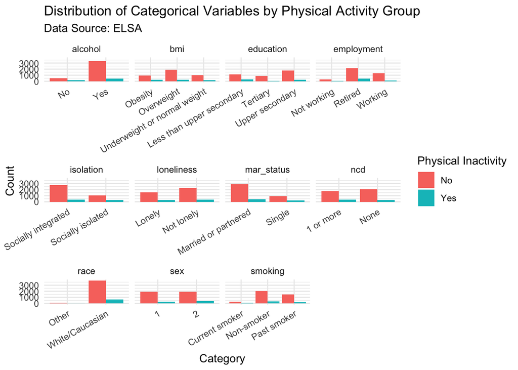

```r
# 图2：按 Physical inactivity 分组的各分类变量分布

dataset_std %>%
  select(physical_inactivity, categorical_vars) %>%
  mutate(across(everything(), ~ as.character(.)))|>
  pivot_longer(cols = -physical_inactivity, names_to = "Variable", values_to = "Value") %>%
  ggplot(aes(x = factor(Value), fill = factor(physical_inactivity))) +
  geom_bar(position = "dodge") +
  facet_wrap(~ Variable, scales = "free_x") +
  labs(
    title = "Distribution of Categorical Variables by Physical Activity Group",
    subtitle = paste("Data Source:", unique(dataset_std$data_source)),
    x = "Category",
    y = "Count",
    fill = "Physical Inactivity"
  ) +
  theme_minimal() +
  theme(axis.text.x = element_text(angle = 30, hjust = 1))
```

# Cox Model——ELSA

## Loneliness

### FIt Cox 模型

```r
# 4. Cox 模型部分
# 模型1：仅包含 loneliness 单变量 Cox 模型
cox_model_lonely_raw <- coxph(Surv(time, event) ~ loneliness, data = dataset_std)

# 模型2：调整人口统计和健康相关协变量的 Cox 模型
cox_model_lonely_adj <- coxph(Surv(time, event) ~ loneliness +
                                age + sex + race + mar_status + education + employment +
                                bmi + smoking + alcohol + ncd,
                              data = dataset_std)

# 模型3：调整physical_inactivity、人口统计和健康相关协变量的 Cox 模型
cox_model_lonely_emm <- coxph(Surv(time, event) ~ loneliness + physical_inactivity +
                                age + sex + race + mar_status + education + employment+
                                bmi + smoking + alcohol + ncd,
                              data = dataset_std)


# 模型4：包含 loneliness 与 physical_inactivity 交互项的 Cox 模型
cox_model_lonely_emm <- coxph(Surv(time, event) ~ loneliness * physical_inactivity +
                                age + sex + race + mar_status + education + employment+
                                bmi + smoking + alcohol + ncd,
                              data = dataset_std)
```

### 提取模型结果用于森林图

```r
# 模型1结果
summary_lonely_raw <- summary(cox_model_lonely_raw)
hr1 <- summary_lonely_raw$conf.int["lonelinessLonely", "exp(coef)"]
lower1 <- summary_lonely_raw$conf.int["lonelinessLonely", "lower .95"]
upper1 <- summary_lonely_raw$conf.int["lonelinessLonely", "upper .95"]
p1 <- summary_lonely_raw$coefficients["lonelinessLonely", "Pr(>|z|)"]

# 模型2结果
summary_lonely_adj <- summary(cox_model_lonely_adj)
hr2 <- summary_lonely_adj$conf.int["lonelinessLonely", "exp(coef)"]
lower2 <- summary_lonely_adj$conf.int["lonelinessLonely", "lower .95"]
upper2 <- summary_lonely_adj$conf.int["lonelinessLonely", "upper .95"]
p2 <- summary_lonely_adj$coefficients["lonelinessLonely", "Pr(>|z|)"]

# 模型3结果
summary_lonely_pi <- summary(cox_model_lonely_pi)
hr3 <- summary_lonely_pi$conf.int["lonelinessLonely", "exp(coef)"]
lower3 <- summary_lonely_pi$conf.int["lonelinessLonely", "lower .95"]
upper3 <- summary_lonely_pi$conf.int["lonelinessLonely", "upper .95"]
p3 <- summary_lonely_pi$coefficients["lonelinessLonely", "Pr(>|z|)"]

# 模型4结果 - loneliness 主效应
summary_lonely_emm <- summary(cox_model_lonely_emm)
hr4 <- summary_lonely_emm$conf.int["lonelinessLonely", "exp(coef)"]
lower4 <- summary_lonely_emm$conf.int["lonelinessLonely", "lower .95"]
upper4 <- summary_lonely_emm$conf.int["lonelinessLonely", "upper .95"]
p4 <- summary_lonely_emm$coefficients["lonelinessLonely", "Pr(>|z|)"]

# 提取交互项效果（假设交互项名称为 "lonelinessLonely:physical_inactivityLow activity"，
# 表示当 physical_inactivity 为 "Low activity" 时，loneliness 效应的额外修正）
interaction_term <- "lonelinessLonely:physical_inactivityYes"
interaction_coef <- summary_lonely_emm$coefficients[interaction_term, "coef"]
interaction_hr   <- summary_lonely_emm$conf.int[interaction_term, "exp(coef)"]
interaction_lower <- summary_lonely_emm$conf.int[interaction_term, "lower .95"]
interaction_upper <- summary_lonely_emm$conf.int[interaction_term, "upper .95"]
interaction_p     <- summary_lonely_emm$coefficients[interaction_term, "Pr(>|z|)"]

cat("交互项 (Loneliness:Physical_inactivity) 效应:\n")
```

```
## 交互项 (Loneliness:Physical_inactivity) 效应:
```

```r
cat("系数:", interaction_coef, "\n")
```

```
## 系数: -0.2568919
```

```r
cat("风险比 (HR):", interaction_hr, "\n")
```

```
## 风险比 (HR): 0.7734518
```

```r
cat("95% CI:", interaction_lower, "-", interaction_upper, "\n")
```

```
## 95% CI: 0.6187645 - 0.96681
```

```r
cat("p值:", interaction_p, "\n\n")
```

```
## p值: 0.02404307
```

```r
###################################
## Multiplicative interaction
###################################
cat("【乘法交互】\n")
```

```
## 【乘法交互】
```

```r
cat("交互项风险比 (exp(beta_interaction)) =", interaction_hr, "\n")
```

```
## 交互项风险比 (exp(beta_interaction)) = 0.7734518
```

```r
cat("95% CI: (", interaction_lower, ",", interaction_upper, ")\n")
```

```
## 95% CI: ( 0.6187645 , 0.96681 )
```

```r
cat("p 值:", interaction_p, "\n\n")
```

```
## p 值: 0.02404307
```

```r
###################################
## Additive interaction (RERI) 计算
###################################
# 提取相关系数（确保名称与模型输出一致）
beta_iso <- summary_lonely_emm$coefficients["lonelinessLonely", "coef"]       # loneliness 主效应
beta_pi  <- summary_lonely_emm$coefficients["physical_inactivityYes", "coef"]  # physical_inactivity 主效应
beta_int <- interaction_coef                                                  # 交互项

# 计算各暴露组合下的风险比
HR10 <- exp(beta_iso)                            # loneliness alone (X=1, Z=0)
HR01 <- exp(beta_pi)                             # physical_inactivity alone (X=0, Z=1)
HR11 <- exp(beta_iso + beta_pi + beta_int)         # 双重暴露 (X=1, Z=1)

RERI <- HR11 - HR10 - HR01 + 1

cat("【加性交互 (RERI)】\n")
```

```
## 【加性交互 (RERI)】
```

```r
cat("HR (loneliness only) =", HR10, "\n")
```

```
## HR (loneliness only) = 1.845765
```

```r
cat("HR (physical inactivity only) =", HR01, "\n")
```

```
## HR (physical inactivity only) = 1.652779
```

```r
cat("HR (both exposures) =", HR11, "\n")
```

```
## HR (both exposures) = 2.359524
```

```r
cat("RERI =", RERI, "\n")
```

```
## RERI = -0.1390197
```

```r
###################################
## 计算 RERI 的95% CI及 p 值（delta 方法）
###################################
# 获取模型协方差矩阵
V <- vcov(cox_model_lonely_emm)
# 按顺序提取相关参数协方差子矩阵（假定参数顺序为 loneliness, physical_inactivity, 交互项）
param_names <- c("lonelinessLonely", "physical_inactivityYes", interaction_term)
V_sub <- V[param_names, param_names]

# 计算 RERI 关于各参数的偏导数
d_beta <- c(
  exp(beta_iso + beta_pi + beta_int) - exp(beta_iso),  # dRERI/d(beta_iso)
  exp(beta_iso + beta_pi + beta_int) - exp(beta_pi),     # dRERI/d(beta_pi)
  exp(beta_iso + beta_pi + beta_int)                     # dRERI/d(beta_int)
)

Var_RERI <- as.numeric(t(d_beta) %*% V_sub %*% d_beta)
SE_RERI <- sqrt(Var_RERI)

RERI_lower <- RERI - 1.96 * SE_RERI
RERI_upper <- RERI + 1.96 * SE_RERI

z_RERI <- RERI / SE_RERI
p_RERI <- 2 * (1 - pnorm(abs(z_RERI)))

cat("\nRERI 的结果：\n")
```

```
##
## RERI 的结果：
```

```r
cat("RERI =", RERI, "\n")
```

```
## RERI = -0.1390197
```

```r
cat("95% CI: (", RERI_lower, ",", RERI_upper, ")\n")
```

```
## 95% CI: ( -0.5684211 , 0.2903818 )
```

```r
cat("z =", z_RERI, "\n")
```

```
## z = -0.6345544
```

```r
cat("p 值 =", p_RERI, "\n")
```

```
## p 值 = 0.5257191
```

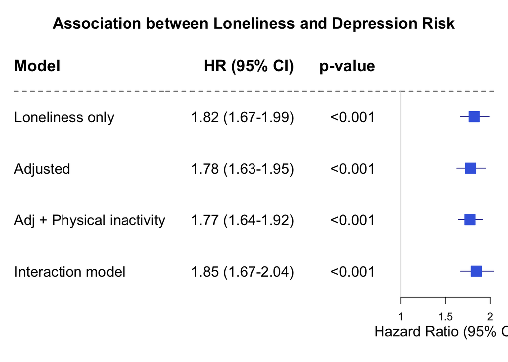

```r
# 准备表格文本
tabletext <- cbind(
  c("Model", "Loneliness only", "Adjusted", "Adj + Physical inactivity", "Interaction model"),
  c("HR (95% CI)",
    paste0(sprintf("%.2f", hr1), " (", sprintf("%.2f", lower1), "-", sprintf("%.2f", upper1), ")"),
    paste0(sprintf("%.2f", hr2), " (", sprintf("%.2f", lower2), "-", sprintf("%.2f", upper2), ")"),
    paste0(sprintf("%.2f", hr3), " (", sprintf("%.2f", lower3), "-", sprintf("%.2f", upper3), ")"),
    paste0(sprintf("%.2f", hr4), " (", sprintf("%.2f", lower4), "-", sprintf("%.2f", upper4), ")")
  ),
  c("p-value",
    ifelse(p1 < 0.001, "<0.001", sprintf("%.3f", p1)),
    ifelse(p2 < 0.001, "<0.001", sprintf("%.3f", p2)),
    ifelse(p3 < 0.001, "<0.001", sprintf("%.3f", p3)),
    ifelse(p4 < 0.001, "<0.001", sprintf("%.3f", p4))
  )
)

forest_data <- data.frame(
  mean = c(NA, hr1, hr2, hr3, hr4),
  lower = c(NA, lower1, lower2, lower3, lower4),
  upper = c(NA, upper1, upper2, upper3, upper4)
)

forestplot(
  labeltext = tabletext,
  mean = forest_data$mean,
  lower = forest_data$lower,
  upper = forest_data$upper,
  is.summary = c(TRUE, FALSE, FALSE, FALSE, FALSE),
  zero = 1,
  boxsize = 0.2,
  lineheight = "auto",
  col = fpColors(box = "royalblue", line = "darkblue", summary = "royalblue"),
  xlab = "Hazard Ratio (95% CI)",
  hrzl_lines = list("2" = gpar(lty = 2)),
  txt_gp = fpTxtGp(label = gpar(cex = 1.2),
                   ticks = gpar(cex = 0.9),
                   xlab = gpar(cex = 1.2),
                   title = gpar(cex = 1.3)),
  title = "Association between Loneliness and Depression Risk"
)
```

###进行似然比检验 (LRT)比较

```r
lrt_result <- anova(cox_model_lonely_adj, cox_model_lonely_emm, test = "LRT")
print(lrt_result)
```

```
## Analysis of Deviance Table
##  Cox model: response is  Surv(time, event)
##  Model 1: ~ loneliness + age + sex + race + mar_status + education + employment + bmi + smoking + alcohol + ncd
##  Model 2: ~ loneliness * physical_inactivity + age + sex + race + mar_status + education + employment + bmi + smoking + alcohol + ncd
##   loglik  Chisq Df Pr(>|Chi|)
## 1 -15875
## 2 -15855 39.872  2  2.197e-09 ***
## ---
## Signif. codes:  0 '***' 0.001 '**' 0.01 '*' 0.05 '.' 0.1 ' ' 1
```

### 亚组分析 - 根据 physical_inactivity

```r
# 身体活跃组（physical_inactivity 为 "No"）
active_group <- dataset_std %>% filter(physical_inactivity == "No")
cox_active <- coxph(Surv(time, event) ~ loneliness + age + sex + race + mar_status + education + employment +
                      bmi + smoking + alcohol + ncd,
                    data = active_group)

# 身体不活跃组（physical_inactivity 为 "Yes"）
inactive_group <- dataset_std %>% filter(physical_inactivity == "Yes")
cox_inactive <- coxph(Surv(time, event) ~ loneliness + age + sex + race + mar_status + education + employment +
                        bmi + smoking + alcohol + ncd,
                      data = inactive_group)

cat("\n亚组 (身体活跃组) 中 Loneliness 的效应:\n")
```

```
##
## 亚组 (身体活跃组) 中 Loneliness 的效应:
```

```r
print(summary(cox_active)$conf.int["lonelinessLonely", c("exp(coef)", "lower .95", "upper .95")])
```

```
## exp(coef) lower .95 upper .95
##  1.844528  1.667165  2.040760
```

```r
cat("p值:", summary(cox_active)$coefficients["lonelinessLonely", "Pr(>|z|)"], "\n")
```

```
## p值: 1.716548e-32
```

```r
cat("\n亚组 (身体不活跃组) 中 Loneliness 的效应:\n")
```

```
##
## 亚组 (身体不活跃组) 中 Loneliness 的效应:
```

```r
print(summary(cox_inactive)$conf.int["lonelinessLonely", c("exp(coef)", "lower .95", "upper .95")])
```

```
## exp(coef) lower .95 upper .95
##  1.429774  1.162280  1.758831
```

```r
cat("p值:", summary(cox_inactive)$coefficients["lonelinessLonely", "Pr(>|z|)"], "\n")
```

```
## p值: 0.0007171158
```

## SSI

```r
###############################
##  Social isolation 模型分析  ##
###############################

# 模型1：仅包含 isolation 单变量 Cox 模型
cox_model_iso_raw <- coxph(Surv(time, event) ~ isolation, data = dataset_std)


# 模型2：调整协变量的 Cox 模型（不含身体活动）
cox_model_iso_adj <- coxph(Surv(time, event) ~ isolation + age + sex + race + mar_status + education + employment +
                             bmi + smoking + alcohol + ncd,
                           data = dataset_std)

# 模型3：在模型中加入 physical_inactivity 作为协变量（调整模型中额外控制身体活动）
cox_model_iso_pi <- coxph(Surv(time, event) ~ isolation + physical_inactivity + age + sex + race + mar_status + education + employment +
                            bmi + smoking + alcohol + ncd,
                          data = dataset_std)

# 模型4：包含 isolation 与 physical_inactivity 交互项的 Cox 模型
cox_model_iso_emm <- coxph(Surv(time, event) ~ isolation * physical_inactivity + age + sex + race + mar_status + education + employment +
                             bmi + smoking + alcohol + ncd,
                           data = dataset_std)
```

### 结果提取及森林图绘制

```r
# 提取模型1结果
summary_iso_raw <- summary(cox_model_iso_raw)
hr_iso1 <- summary_iso_raw$conf.int["isolationSocially isolated", "exp(coef)"]
lower_ci_iso1 <- summary_iso_raw$conf.int["isolationSocially isolated", "lower .95"]
upper_ci_iso1 <- summary_iso_raw$conf.int["isolationSocially isolated", "upper .95"]
p_val_iso1 <- summary_iso_raw$coefficients["isolationSocially isolated", "Pr(>|z|)"]

# 模型2结果
summary_iso_adj <- summary(cox_model_iso_adj)
hr_iso2 <- summary_iso_adj$conf.int["isolationSocially isolated", "exp(coef)"]
lower_ci_iso2 <- summary_iso_adj$conf.int["isolationSocially isolated", "lower .95"]
upper_ci_iso2 <- summary_iso_adj$conf.int["isolationSocially isolated", "upper .95"]
p_val_iso2 <- summary_iso_adj$coefficients["isolationSocially isolated", "Pr(>|z|)"]

# 模型3结果
summary_iso_pi <- summary(cox_model_iso_pi)
hr_iso3 <- summary_iso_pi$conf.int["isolationSocially isolated", "exp(coef)"]
lower_ci_iso3 <- summary_iso_pi$conf.int["isolationSocially isolated", "lower .95"]
upper_ci_iso3 <- summary_iso_pi$conf.int["isolationSocially isolated", "upper .95"]
p_val_iso3 <- summary_iso_pi$coefficients["isolationSocially isolated", "Pr(>|z|)"]

# 模型4结果 - isolation 主效应
summary_iso_emm <- summary(cox_model_iso_emm)
hr_iso4 <- summary_iso_emm$conf.int["isolationSocially isolated", "exp(coef)"]
lower_ci_iso4 <- summary_iso_emm$conf.int["isolationSocially isolated", "lower .95"]
upper_ci_iso4 <- summary_iso_emm$conf.int["isolationSocially isolated", "upper .95"]
p_val_iso4 <- summary_iso_emm$coefficients["isolationSocially isolated", "Pr(>|z|)"]

# 交互项效果提取（假设交互项名称为 "isolationIsolated:physical_inactivityLow activity"，
# 表示当 physical_inactivity 为 "Low activity" 时，isolation 的额外修正）
interaction_term_iso <- "isolationSocially isolated:physical_inactivityYes"
interaction_coef_iso <- summary_iso_emm$coefficients[interaction_term_iso, "coef"]
interaction_hr_iso   <- summary_iso_emm$conf.int[interaction_term_iso, "exp(coef)"]
interaction_lower_iso <- summary_iso_emm$conf.int[interaction_term_iso, "lower .95"]
interaction_upper_iso <- summary_iso_emm$conf.int[interaction_term_iso, "upper .95"]
interaction_p_iso     <- summary_iso_emm$coefficients[interaction_term_iso, "Pr(>|z|)"]

cat("交互项 (Isolation:Physical_inactivity) 效应:\n")
```

```
## 交互项 (Isolation:Physical_inactivity) 效应:
```

```r
cat("系数:", interaction_coef_iso, "\n")
```

```
## 系数: 0.09599853
```

```r
cat("风险比 (HR):", interaction_hr_iso, "\n")
```

```
## 风险比 (HR): 1.100757
```

```r
cat("95% CI:", interaction_lower_iso, "-", interaction_upper_iso, "\n")
```

```
## 95% CI: 0.8765557 - 1.382305
```

```r
cat("p值:", interaction_p_iso, "\n")
```

```
## p值: 0.4087312
```

```r
######################################
## Multiplicative interaction
######################################
cat("【乘法交互】\n")
```

```
## 【乘法交互】
```

```r
cat("交互项风险比 (exp(beta_interaction)) =", interaction_hr_iso, "\n")
```

```
## 交互项风险比 (exp(beta_interaction)) = 1.100757
```

```r
cat("95% CI: (", interaction_lower_iso, ",", interaction_upper_iso, ")\n")
```

```
## 95% CI: ( 0.8765557 , 1.382305 )
```

```r
cat("p 值:", interaction_p_iso, "\n\n")
```

```
## p 值: 0.4087312
```

```r
######################################
## Additive interaction (RERI) 计算
######################################
# 提取模型4中各相关系数（请确保名称与模型输出一致）
beta_iso <- summary_iso_emm$coefficients["isolationSocially isolated", "coef"]      # isolation 主效应
beta_pi  <- summary_iso_emm$coefficients["physical_inactivityYes", "coef"]             # physical_inactivity 主效应
beta_int <- interaction_coef_iso                                                    # 交互项

# 计算各种暴露组合下的风险比
HR10 <- exp(beta_iso)                       # isolation alone (when physical_inactivity = 0)
HR01 <- exp(beta_pi)                        # physical_inactivity alone (when isolation = 0)
HR11 <- exp(beta_iso + beta_pi + beta_int)    # both exposures (isolation and physical_inactivity)

# RERI 计算公式
RERI <- HR11 - HR10 - HR01 + 1

cat("【加性交互 (RERI)】\n")
```

```
## 【加性交互 (RERI)】
```

```r
cat("HR (isolation only) =", HR10, "\n")
```

```
## HR (isolation only) = 1.068376
```

```r
cat("HR (physical inactivity only) =", HR01, "\n")
```

```
## HR (physical inactivity only) = 1.415559
```

```r
cat("HR (both exposures) =", HR11, "\n")
```

```
## HR (both exposures) = 1.66473
```

```r
cat("RERI =", RERI, "\n")
```

```
## RERI = 0.1807948
```

```r
######################################
## 计算 RERI 的95% CI和 p 值（delta方法）
######################################
# 获取交互模型中相关系数的协方差矩阵
V <- vcov(cox_model_iso_emm)
# 提取相关参数的协方差子矩阵，按顺序为 isolation, physical_inactivity, 交互项
param_names <- c("isolationSocially isolated", "physical_inactivityYes", interaction_term_iso)
V_sub <- V[param_names, param_names]

# 计算 RERI 关于各个参数的偏导数
# dRERI/dβ_iso = exp(β_iso + β_pi + β_int) - exp(β_iso)
# dRERI/dβ_pi  = exp(β_iso + β_pi + β_int) - exp(β_pi)
# dRERI/dβ_int = exp(β_iso + β_pi + β_int)
d_beta <- c(
  exp(beta_iso + beta_pi + beta_int) - exp(beta_iso),
  exp(beta_iso + beta_pi + beta_int) - exp(beta_pi),
  exp(beta_iso + beta_pi + beta_int)
)

# 计算 RERI 的方差：Var(RERI) = d_beta' * V_sub * d_beta
Var_RERI <- as.numeric(t(d_beta) %*% V_sub %*% d_beta)
SE_RERI <- sqrt(Var_RERI)

# 计算95% CI
RERI_lower <- RERI - 1.96 * SE_RERI
RERI_upper <- RERI + 1.96 * SE_RERI

# 计算针对 RERI 的 z 统计量和 p 值
z_RERI <- RERI / SE_RERI
p_RERI <- 2 * (1 - pnorm(abs(z_RERI)))

cat("\nRERI 的结果：\n")
```

```
##
## RERI 的结果：
```

```r
cat("RERI =", RERI, "\n")
```

```
## RERI = 0.1807948
```

```r
cat("95% CI: (", RERI_lower, ",", RERI_upper, ")\n")
```

```
## 95% CI: ( -0.1504091 , 0.5119988 )
```

```r
cat("z =", z_RERI, "\n")
```

```
## z = 1.069908
```

```r
cat("p 值 =", p_RERI, "\n")
```

```
## p 值 = 0.2846606
```

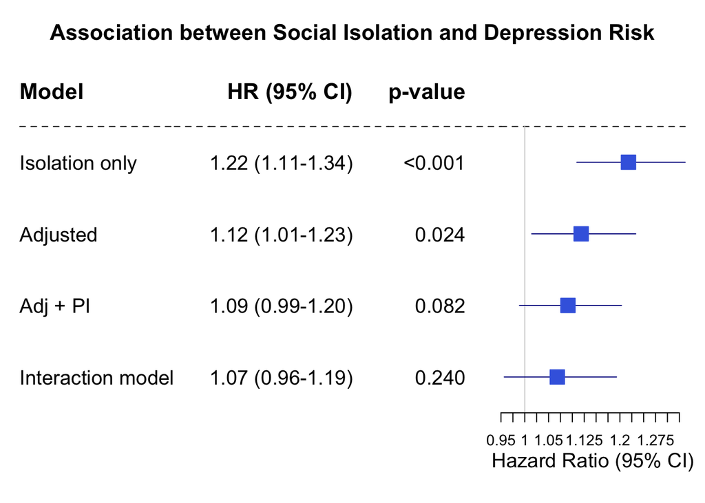

```r
##################################
## 森林图绘制 - Social Isolation 系列
##################################
tabletext_iso <- cbind(
  c("Model", "Isolation only", "Adjusted", "Adj + PI", "Interaction model"),
  c("HR (95% CI)",
    paste0(sprintf("%.2f", hr_iso1), " (", sprintf("%.2f", lower_ci_iso1), "-", sprintf("%.2f", upper_ci_iso1), ")"),
    paste0(sprintf("%.2f", hr_iso2), " (", sprintf("%.2f", lower_ci_iso2), "-", sprintf("%.2f", upper_ci_iso2), ")"),
    paste0(sprintf("%.2f", hr_iso3), " (", sprintf("%.2f", lower_ci_iso3), "-", sprintf("%.2f", upper_ci_iso3), ")"),
    paste0(sprintf("%.2f", hr_iso4), " (", sprintf("%.2f", lower_ci_iso4), "-", sprintf("%.2f", upper_ci_iso4), ")")
  ),
  c("p-value",
    ifelse(p_val_iso1 < 0.001, "<0.001", sprintf("%.3f", p_val_iso1)),
    ifelse(p_val_iso2 < 0.001, "<0.001", sprintf("%.3f", p_val_iso2)),
    ifelse(p_val_iso3 < 0.001, "<0.001", sprintf("%.3f", p_val_iso3)),
    ifelse(p_val_iso4 < 0.001, "<0.001", sprintf("%.3f", p_val_iso4))
  )
)

forest_data_iso <- data.frame(
  mean = c(NA, hr_iso1, hr_iso2, hr_iso3, hr_iso4),
  lower = c(NA, lower_ci_iso1, lower_ci_iso2, lower_ci_iso3, lower_ci_iso4),
  upper = c(NA, upper_ci_iso1, upper_ci_iso2, upper_ci_iso3, upper_ci_iso4)
)

forestplot(
  labeltext = tabletext_iso,
  mean = forest_data_iso$mean,
  lower = forest_data_iso$lower,
  upper = forest_data_iso$upper,
  is.summary = c(TRUE, FALSE, FALSE, FALSE, FALSE),
  zero = 1,
  boxsize = 0.2,
  lineheight = "auto",
  col = fpColors(box = "royalblue", line = "darkblue", summary = "royalblue"),
  xlab = "Hazard Ratio (95% CI)",
  hrzl_lines = list("2" = gpar(lty = 2)),
  txt_gp = fpTxtGp(label = gpar(cex = 1.2),
                   ticks = gpar(cex = 0.9),
                   xlab = gpar(cex = 1.2),
                   title = gpar(cex = 1.3)),
  title = "Association between Social Isolation and Depression Risk"
)
```

```r
######################################
## LRT 检验 - 比较模型2 与模型4 (Social Isolation)
######################################
lrt_result_iso <- anova(cox_model_iso_adj, cox_model_iso_emm, test = "LRT")
print(lrt_result_iso)
```

```
## Analysis of Deviance Table
##  Cox model: response is  Surv(time, event)
##  Model 1: ~ isolation + age + sex + race + mar_status + education + employment + bmi + smoking + alcohol + ncd
##  Model 2: ~ isolation * physical_inactivity + age + sex + race + mar_status + education + employment + bmi + smoking + alcohol + ncd
##   loglik  Chisq Df Pr(>|Chi|)
## 1 -15950
## 2 -15929 41.001  2  1.249e-09 ***
## ---
## Signif. codes:  0 '***' 0.001 '**' 0.01 '*' 0.05 '.' 0.1 ' ' 1
```

```r
#################################
## 亚组分析：根据 physical_inactivity 分组 ##
#################################
# 身体活跃组（physical_inactivity 为 "No"）
active_group <- dataset_std %>% filter(physical_inactivity == "No")
cox_active_iso <- coxph(Surv(time, event) ~ isolation + age + sex + race + mar_status + education + employment +
                          bmi + smoking + alcohol + ncd,
                        data = active_group)
# 身体不活跃组（physical_inactivity 为 "Yes"）
inactive_group <- dataset_std %>% filter(physical_inactivity == "Yes")
cox_inactive_iso <- coxph(Surv(time, event) ~ isolation + age + sex + race + mar_status + education + employment +
                            bmi + smoking + alcohol + ncd,
                          data = inactive_group)

cat("\n身体活跃组中 Isolation 的效应:\n")
```

```
##
## 身体活跃组中 Isolation 的效应:
```

```r
print(summary(cox_active_iso)$conf.int["isolationSocially isolated", c("exp(coef)", "lower .95", "upper .95")])
```

```
## exp(coef) lower .95 upper .95
## 1.0655498 0.9537025 1.1905143
```

```r
cat("p值:", summary(cox_active_iso)$coefficients["isolationSocially isolated", "Pr(>|z|)"], "\n")
```

```
## p值: 0.2617997
```

```r
cat("\n身体不活跃组中 Isolation 的效应:\n")
```

```
##
## 身体不活跃组中 Isolation 的效应:
```

```r
print(summary(cox_inactive_iso)$conf.int["isolationSocially isolated", c("exp(coef)", "lower .95", "upper .95")])
```

```
## exp(coef) lower .95 upper .95
## 1.1928788 0.9597277 1.4826703
```

```r
cat("p值:", summary(cox_inactive_iso)$coefficients["isolationSocially isolated", "Pr(>|z|)"], "\n")
```

```
## p值: 0.1119464
```

# 2012–2018 for MHAS (waves 3–5)

## Load data

```r
mhas <- read_dta("./data/H_MHAS_c2.dta")
```